# CaseStudy2DDS

Blaine Brewer

April 18, 2019

link to the youtube presentation: https://youtu.be/1fHFSlSYd2E

Importing Data

```r
# download.file('https://raw.githubusercontent.com/newtgunslinger/MSDS-6306-Doing-Data-Science/master/UNIT%2014/CaseStudy2-data.csv', destfile = "CaseStudyData_Income.csv", method = "curl")
income.df <- read.csv('CaseStudyData_Income.csv')
head(income.df)
```

```
##   ID Age Attrition    BusinessTravel DailyRate             Department
## 1  1  32        No     Travel_Rarely       117                  Sales
## 2  2  40        No     Travel_Rarely      1308 Research & Development
## 3  3  35        No Travel_Frequently       200 Research & Development
## 4  4  32        No     Travel_Rarely       801                  Sales
## 5  5  24        No Travel_Frequently       567 Research & Development
## 6  6  27        No Travel_Frequently       294 Research & Development
##   DistanceFromHome Education   EducationField EmployeeCount EmployeeNumber
## 1               13         4    Life Sciences             1            859
## 2               14         3          Medical             1           1128
## 3               18         2    Life Sciences             1           1412
## 4                1         4        Marketing             1           2016
## 5                2         1 Technical Degree             1           1646
## 6               10         2    Life Sciences             1            733
##   EnvironmentSatisfaction Gender HourlyRate JobInvolvement JobLevel
```

[output cut: 48 more lines]

```r
# download.file('https://raw.githubusercontent.com/newtgunslinger/MSDS-6306-Doing-Data-Science/master/UNIT%2014/CaseStudy2Validation%20No%20Attrition.csv', destfile = "CaseStudyData_ValNoAttrition.csv", method = "curl")
no.attrition.df <- read.csv('CaseStudyData_ValNoAttrition.csv')
head(no.attrition.df)
```

```
##     ID Age    BusinessTravel DailyRate             Department
## 1 1171  35     Travel_Rarely       750 Research & Development
## 2 1172  33     Travel_Rarely       147        Human Resources
## 3 1173  26     Travel_Rarely      1330 Research & Development
## 4 1174  55     Travel_Rarely      1311 Research & Development
## 5 1175  29     Travel_Rarely      1246                  Sales
## 6 1176  51 Travel_Frequently      1456 Research & Development
##   DistanceFromHome Education  EducationField EmployeeCount EmployeeNumber
## 1               28         3   Life Sciences             1           1596
## 2                2         3 Human Resources             1           1207
## 3               21         3         Medical             1           1107
## 4                2         3   Life Sciences             1            505
## 5               19         3   Life Sciences             1           1497
## 6                1         4         Medical             1            145
##   EnvironmentSatisfaction Gender HourlyRate JobInvolvement JobLevel
```

[output cut: 48 more lines]

```r
no.salary.df <- read.csv("CaseStudy2Validation No Salary.csv")
head(no.salary.df)
```

```
##    ID Age Attrition    BusinessTravel DailyRate             Department
## 1 871  43        No Travel_Frequently      1422                  Sales
## 2 872  33        No     Travel_Rarely       461 Research & Development
## 3 873  55       Yes     Travel_Rarely       267                  Sales
## 4 874  36        No        Non-Travel      1351 Research & Development
## 5 875  27        No     Travel_Rarely      1302 Research & Development
## 6 876  39       Yes     Travel_Rarely       895                  Sales
##   DistanceFromHome Education   EducationField EmployeeCount EmployeeNumber
## 1                2         4    Life Sciences             1           1849
## 2               13         1    Life Sciences             1            995
## 3               13         4        Marketing             1           1372
## 4                9         4    Life Sciences             1           1949
## 5               19         3            Other             1           1619
## 6                5         3 Technical Degree             1             42
##   EnvironmentSatisfaction Gender HourlyRate JobInvolvement JobLevel
```

[output cut: 48 more lines]

Exploratory Data Analysis

```r
dim(income.df)
```

```
## [1] 870  37
```

```r
dim(no.attrition.df)
```

```
## [1] 300  36
```

```r
summary(income.df)
```

```
##        ID             Age        Attrition           BusinessTravel
##  Min.   :  1.0   Min.   :18.00   No :730   Non-Travel       : 94
##  1st Qu.:218.2   1st Qu.:30.00   Yes:140   Travel_Frequently:158
##  Median :435.5   Median :35.00             Travel_Rarely    :618
##  Mean   :435.5   Mean   :36.83
##  3rd Qu.:652.8   3rd Qu.:43.00
##  Max.   :870.0   Max.   :60.00
##
##    DailyRate                       Department  DistanceFromHome
##  Min.   : 103.0   Human Resources       : 35   Min.   : 1.000
##  1st Qu.: 472.5   Research & Development:562   1st Qu.: 2.000
##  Median : 817.5   Sales                 :273   Median : 7.000
##  Mean   : 815.2                                Mean   : 9.339
##  3rd Qu.:1165.8                                3rd Qu.:14.000
##  Max.   :1499.0                                Max.   :29.000
##
##    Education              EducationField EmployeeCount EmployeeNumber
##  Min.   :1.000   Human Resources : 15    Min.   :1     Min.   :   1.0
##  1st Qu.:2.000   Life Sciences   :358    1st Qu.:1     1st Qu.: 477.2
##  Median :3.000   Marketing       :100    Median :1     Median :1039.0
##  Mean   :2.901   Medical         :270    Mean   :1     Mean   :1029.8
##  3rd Qu.:4.000   Other           : 52    3rd Qu.:1     3rd Qu.:1561.5
##  Max.   :5.000   Technical Degree: 75    Max.   :1     Max.   :2064.0
##
##  EnvironmentSatisfaction    Gender      HourlyRate     JobInvolvement
##  Min.   :1.000           Female:354   Min.   : 30.00   Min.   :1.000
##  1st Qu.:2.000           Male  :516   1st Qu.: 48.00   1st Qu.:2.000
##  Median :3.000                        Median : 66.00   Median :3.000
##  Mean   :2.701                        Mean   : 65.61   Mean   :2.723
##  3rd Qu.:4.000                        3rd Qu.: 83.00   3rd Qu.:3.000
##  Max.   :4.000                        Max.   :100.00   Max.   :4.000
##
##     JobLevel                          JobRole    JobSatisfaction
##  Min.   :1.000   Sales Executive          :200   Min.   :1.000
##  1st Qu.:1.000   Research Scientist       :172   1st Qu.:2.000
##  Median :2.000   Laboratory Technician    :153   Median :3.000
##  Mean   :2.039   Manufacturing Director   : 87   Mean   :2.709
##  3rd Qu.:3.000   Healthcare Representative: 76   3rd Qu.:4.000
##  Max.   :5.000   Sales Representative     : 53   Max.   :4.000
##                  (Other)                  :129
```

[output cut: 25 more lines]

```
##  Min.   :1.000   Min.   : 0.000   Min.   : 0.000
##  1st Qu.:2.000   1st Qu.: 3.000   1st Qu.: 2.000
##  Median :3.000   Median : 5.000   Median : 3.000
##  Mean   :2.782   Mean   : 6.962   Mean   : 4.205
##  3rd Qu.:3.000   3rd Qu.:10.000   3rd Qu.: 7.000
##  Max.   :4.000   Max.   :40.000   Max.   :18.000
##
##  YearsSinceLastPromotion YearsWithCurrManager      Rand
##  Min.   : 0.000          Min.   : 0.00        Min.   :-3.0194
##  1st Qu.: 0.000          1st Qu.: 2.00        1st Qu.:-0.8907
##  Median : 1.000          Median : 3.00        Median :-0.3238
##  Mean   : 2.169          Mean   : 4.14        Mean   :-0.4394
##  3rd Qu.: 3.000          3rd Qu.: 7.00        3rd Qu.: 0.1136
##  Max.   :15.000          Max.   :17.00        Max.   : 0.9997
##
```

```r
str(income.df)
```

```
## 'data.frame':    870 obs. of  37 variables:
##  $ ID                      : int  1 2 3 4 5 6 7 8 9 10 ...
##  $ Age                     : int  32 40 35 32 24 27 41 37 34 34 ...
##  $ Attrition               : Factor w/ 2 levels "No","Yes": 1 1 1 1 1 1 1 1 1 1 ...
##  $ BusinessTravel          : Factor w/ 3 levels "Non-Travel","Travel_Frequently",..: 3 3 2 3 2 2 3 3 3 2 ...
##  $ DailyRate               : int  117 1308 200 801 567 294 1283 309 1333 653 ...
##  $ Department              : Factor w/ 3 levels "Human Resources",..: 3 2 2 3 2 2 2 3 3 2 ...
##  $ DistanceFromHome        : int  13 14 18 1 2 10 5 10 10 10 ...
##  $ Education               : int  4 3 2 4 1 2 5 4 4 4 ...
##  $ EducationField          : Factor w/ 6 levels "Human Resources",..: 2 4 2 3 6 2 4 2 2 6 ...
##  $ EmployeeCount           : int  1 1 1 1 1 1 1 1 1 1 ...
##  $ EmployeeNumber          : int  859 1128 1412 2016 1646 733 1448 1105 1055 1597 ...
##  $ EnvironmentSatisfaction : int  2 3 3 3 1 4 2 4 3 4 ...
##  $ Gender                  : Factor w/ 2 levels "Female","Male": 2 2 2 1 1 2 2 1 1 2 ...
##  $ HourlyRate              : int  73 44 60 48 32 32 90 88 87 92 ...
```

[output cut: 23 more lines]

how many levels are available with employee count and over18

```r
unique(income.df$EmployeeCount)
```

```
## [1] 1
```

```r
unique(income.df$Over18)
```

```
## [1] Y
## Levels: Y
```

drop employee count, employee number, Over 18, standard hours, id and the random variable from the analysis

```r
income.df$EmployeeCount = NULL
income.df$EmployeeNumber = NULL
income.df$Over18 = NULL
income.df$StandardHours = NULL
income.df$ID = NULL
income.df$Rand = NULL
```

check for NAs

```r
check.na <- as.data.frame(sapply(income.df, function(x) {sum(is.na(x))}))
names(check.na) <- ""
check.na
```

```
##
## Age                      0
## Attrition                0
## BusinessTravel           0
## DailyRate                0
## Department               0
## DistanceFromHome         0
## Education                0
## EducationField           0
## EnvironmentSatisfaction  0
## Gender                   0
## HourlyRate               0
## JobInvolvement           0
## JobLevel                 0
## JobRole                  0
## JobSatisfaction          0
## MaritalStatus            0
## MonthlyIncome            0
## MonthlyRate              0
## NumCompaniesWorked       0
## OverTime                 0
## PercentSalaryHike        0
## PerformanceRating        0
## RelationshipSatisfaction 0
## StockOptionLevel         0
## TotalWorkingYears        0
## TrainingTimesLastYear    0
## WorkLifeBalance          0
## YearsAtCompany           0
## YearsInCurrentRole       0
## YearsSinceLastPromotion  0
## YearsWithCurrManager     0
```

check for multicolinearity

```r
# check for multicoliniarity
str(income.df)
```

```
## 'data.frame':    870 obs. of  31 variables:
##  $ Age                     : int  32 40 35 32 24 27 41 37 34 34 ...
##  $ Attrition               : Factor w/ 2 levels "No","Yes": 1 1 1 1 1 1 1 1 1 1 ...
##  $ BusinessTravel          : Factor w/ 3 levels "Non-Travel","Travel_Frequently",..: 3 3 2 3 2 2 3 3 3 2 ...
##  $ DailyRate               : int  117 1308 200 801 567 294 1283 309 1333 653 ...
##  $ Department              : Factor w/ 3 levels "Human Resources",..: 3 2 2 3 2 2 2 3 3 2 ...
##  $ DistanceFromHome        : int  13 14 18 1 2 10 5 10 10 10 ...
##  $ Education               : int  4 3 2 4 1 2 5 4 4 4 ...
##  $ EducationField          : Factor w/ 6 levels "Human Resources",..: 2 4 2 3 6 2 4 2 2 6 ...
##  $ EnvironmentSatisfaction : int  2 3 3 3 1 4 2 4 3 4 ...
##  $ Gender                  : Factor w/ 2 levels "Female","Male": 2 2 2 1 1 2 2 1 1 2 ...
##  $ HourlyRate              : int  73 44 60 48 32 32 90 88 87 92 ...
##  $ JobInvolvement          : int  3 2 3 3 3 3 4 2 3 2 ...
##  $ JobLevel                : int  2 5 3 3 1 3 1 2 1 2 ...
##  $ JobRole                 : Factor w/ 9 levels "Healthcare Representative",..: 8 6 5 8 7 5 7 8 9 1 ...
```

[output cut: 17 more lines]

```r
var.class <- sapply(income.df, class)
var.class %in% c("integer","numeric")
```

```
##  [1]  TRUE FALSE FALSE  TRUE FALSE  TRUE  TRUE FALSE  TRUE FALSE  TRUE
## [12]  TRUE  TRUE FALSE  TRUE FALSE  TRUE  TRUE  TRUE FALSE  TRUE  TRUE
## [23]  TRUE  TRUE  TRUE  TRUE  TRUE  TRUE  TRUE  TRUE  TRUE
```

```r
cont.class <- var.class %in% c("integer","numeric")
cont.var <- names(income.df)[cont.class]
cont.var
```

```
##  [1] "Age"                      "DailyRate"
##  [3] "DistanceFromHome"         "Education"
##  [5] "EnvironmentSatisfaction"  "HourlyRate"
##  [7] "JobInvolvement"           "JobLevel"
##  [9] "JobSatisfaction"          "MonthlyIncome"
## [11] "MonthlyRate"              "NumCompaniesWorked"
## [13] "PercentSalaryHike"        "PerformanceRating"
## [15] "RelationshipSatisfaction" "StockOptionLevel"
## [17] "TotalWorkingYears"        "TrainingTimesLastYear"
## [19] "WorkLifeBalance"          "YearsAtCompany"
## [21] "YearsInCurrentRole"       "YearsSinceLastPromotion"
## [23] "YearsWithCurrManager"
```

```r
var.class
```

```
##                      Age                Attrition           BusinessTravel
##                "integer"                 "factor"                 "factor"
##                DailyRate               Department         DistanceFromHome
##                "integer"                 "factor"                "integer"
##                Education           EducationField  EnvironmentSatisfaction
##                "integer"                 "factor"                "integer"
##                   Gender               HourlyRate           JobInvolvement
##                 "factor"                "integer"                "integer"
##                 JobLevel                  JobRole          JobSatisfaction
##                "integer"                 "factor"                "integer"
##            MaritalStatus            MonthlyIncome              MonthlyRate
##                 "factor"                "integer"                "integer"
##       NumCompaniesWorked                 OverTime        PercentSalaryHike
##                "integer"                 "factor"                "integer"
##        PerformanceRating RelationshipSatisfaction         StockOptionLevel
##                "integer"                "integer"                "integer"
##        TotalWorkingYears    TrainingTimesLastYear          WorkLifeBalance
##                "integer"                "integer"                "integer"
##           YearsAtCompany       YearsInCurrentRole  YearsSinceLastPromotion
##                "integer"                "integer"                "integer"
##     YearsWithCurrManager
##                "integer"
```

```r
cat.df <- income.df[,!(names(income.df) %in% cont.var)]
table(cat.df$BusinessTravel, cat.df$Attrition)
```

```
##
##                      No Yes
##   Non-Travel         83  11
##   Travel_Frequently 123  35
##   Travel_Rarely     524  94
```

```r
table(cat.df$Department, cat.df$Attrition)
```

```
##
##                           No Yes
##   Human Resources         29   6
##   Research & Development 487  75
##   Sales                  214  59
```

```r
table(cat.df$EducationField, cat.df$Attrition)
```

```
##
##                     No Yes
##   Human Resources   11   4
##   Life Sciences    305  53
##   Marketing         80  20
##   Medical          233  37
##   Other             43   9
##   Technical Degree  58  17
```

```r
table(cat.df$Gender, cat.df$Attrition)
```

```
##
##           No Yes
##   Female 301  53
##   Male   429  87
```

```r
table(cat.df$MaritalStatus, cat.df$Attrition)
```

```
##
##             No Yes
##   Divorced 179  12
##   Married  352  58
##   Single   199  70
```

```r
table(cat.df$OverTime, cat.df$Attrition)
```

```
##
##        No Yes
##   No  558  60
##   Yes 172  80
```

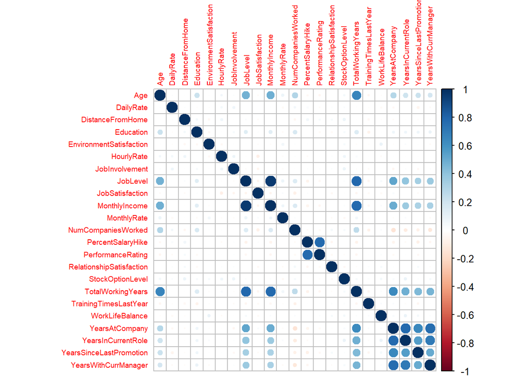

```r
cont.income <- income.df[,cont.var]

#Checking for collinearity
corrplot(cor(cont.income), tl.cex = 0.6)
```

```r
job.level.cor <- as.data.frame(cor(cont.income)["JobLevel",])
names(job.level.cor) <- "Correlation"
job.level.cor <- data.frame(Variable=row.names(job.level.cor), Correlation = job.level.cor)
head(job.level.cor)
```

```
##                                        Variable   Correlation
## Age                                         Age  0.4794235642
## DailyRate                             DailyRate  0.0018376264
## DistanceFromHome               DistanceFromHome  0.0217270544
## Education                             Education  0.1303859075
## EnvironmentSatisfaction EnvironmentSatisfaction  0.0001545152
## HourlyRate                           HourlyRate -0.0080700744
```

```r
order.cor <- order(job.level.cor$Correlation, decreasing = T)
job.level.cor <- job.level.cor[order.cor,]
row.names(job.level.cor) <- 1:nrow(job.level.cor )
job.level.cor
```

```
##                    Variable   Correlation
## 1                  JobLevel  1.0000000000
## 2             MonthlyIncome  0.9516400488
## 3         TotalWorkingYears  0.7807523526
## 4            YearsAtCompany  0.5205835070
## 5                       Age  0.4794235642
## 6        YearsInCurrentRole  0.3913048192
## 7      YearsWithCurrManager  0.3665674724
## 8   YearsSinceLastPromotion  0.3304357051
## 9        NumCompaniesWorked  0.1408348284
## 10                Education  0.1303859075
## 11              MonthlyRate  0.0744538290
## 12          WorkLifeBalance  0.0302838677
## 13         DistanceFromHome  0.0217270544
## 14         StockOptionLevel  0.0188872312
## 15                DailyRate  0.0018376264
## 16  EnvironmentSatisfaction  0.0001545152
## 17 RelationshipSatisfaction -0.0048204622
## 18               HourlyRate -0.0080700744
## 19           JobInvolvement -0.0158750522
## 20        PerformanceRating -0.0386966885
## 21    TrainingTimesLastYear -0.0458643163
## 22          JobSatisfaction -0.0503060650
## 23        PercentSalaryHike -0.0622671489
```

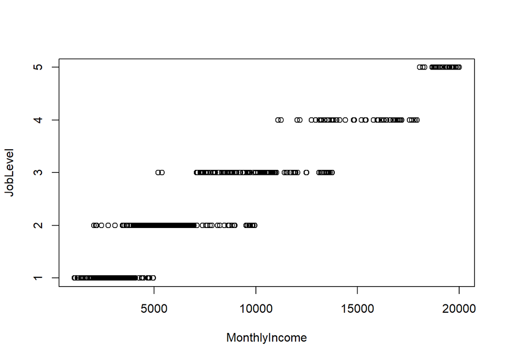

```r
plot(JobLevel ~ MonthlyIncome, data = income.df)
```

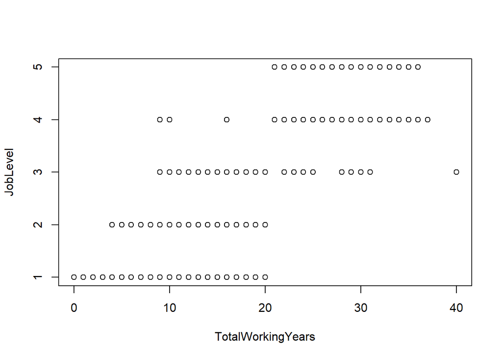

```r
plot(JobLevel ~ TotalWorkingYears, data = income.df)
```

```r
working.years.cor <- as.data.frame(cor(cont.income)["TotalWorkingYears",])
names(working.years.cor) <- "Correlation"
working.years.cor <- data.frame(Variable=row.names(working.years.cor), Correlation = working.years.cor)
head(working.years.cor)
```

```
##                                        Variable  Correlation
## Age                                         Age  0.652613137
## DailyRate                             DailyRate -0.007402129
## DistanceFromHome               DistanceFromHome  0.004186191
## Education                             Education  0.146044538
## EnvironmentSatisfaction EnvironmentSatisfaction -0.019956530
## HourlyRate                           HourlyRate  0.029476711
```

```r
order.cor <- order(working.years.cor$Correlation, decreasing = T)
working.years.cor <- working.years.cor[order.cor,]
row.names(working.years.cor) <- 1:nrow(working.years.cor )
working.years.cor
```

```
##                    Variable  Correlation
## 1         TotalWorkingYears  1.000000000
## 2                  JobLevel  0.780752353
## 3             MonthlyIncome  0.778511205
## 4                       Age  0.652613137
## 5            YearsAtCompany  0.636083586
## 6        YearsInCurrentRole  0.486590295
## 7      YearsWithCurrManager  0.461485375
## 8   YearsSinceLastPromotion  0.445838540
## 9        NumCompaniesWorked  0.258099959
## 10                Education  0.146044538
## 11              MonthlyRate  0.057889875
## 12         StockOptionLevel  0.036235025
## 13               HourlyRate  0.029476711
## 14          WorkLifeBalance  0.018724536
## 15         DistanceFromHome  0.004186191
## 16                DailyRate -0.007402129
## 17           JobInvolvement -0.013986410
## 18 RelationshipSatisfaction -0.017575299
## 19  EnvironmentSatisfaction -0.019956530
## 20        PerformanceRating -0.041377258
## 21    TrainingTimesLastYear -0.041912467
## 22          JobSatisfaction -0.049281026
## 23        PercentSalaryHike -0.064304461
```

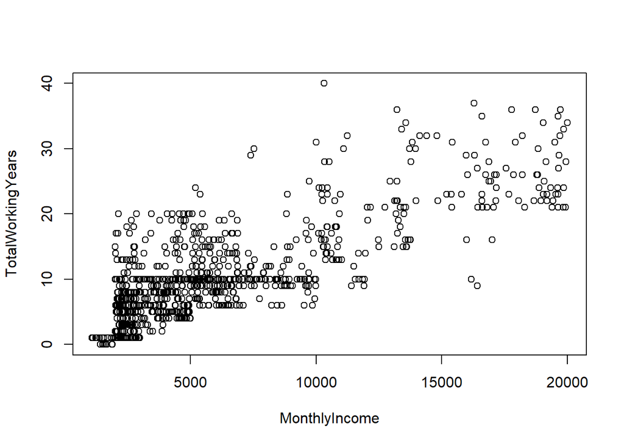

```r
plot(TotalWorkingYears ~ MonthlyIncome, data = income.df)
```

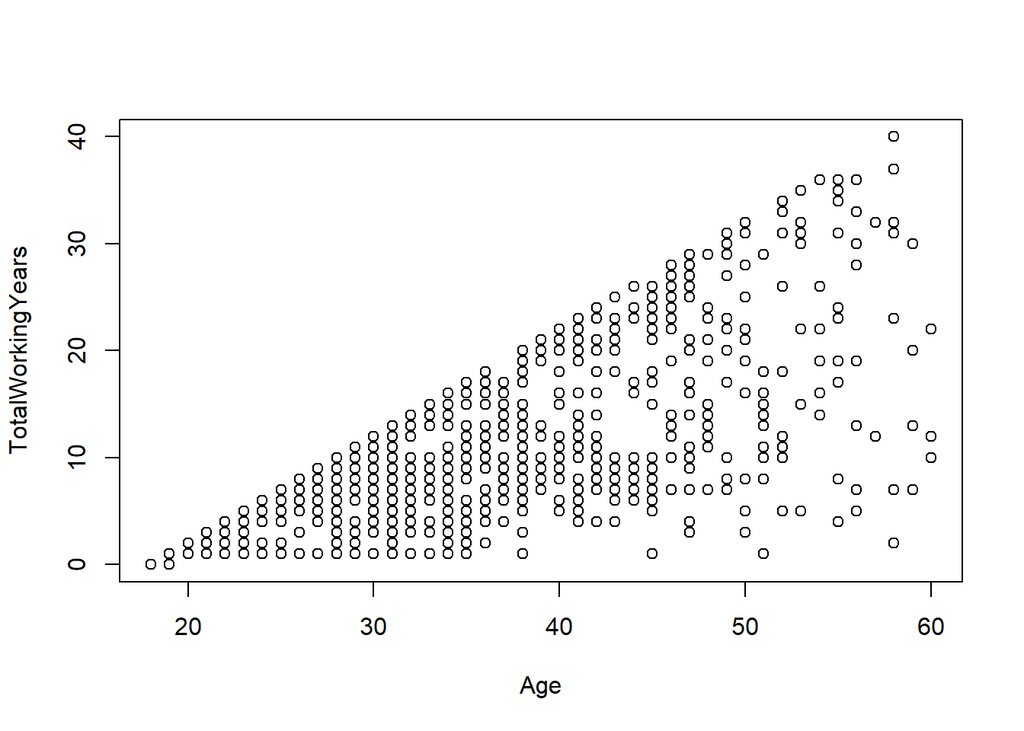

```r
plot(TotalWorkingYears ~ Age, data = income.df)
```

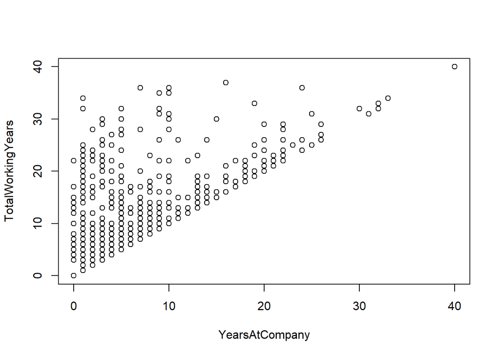

```r
plot(TotalWorkingYears ~ YearsAtCompany, data = income.df)
```

```r
years.company.cor <- as.data.frame(cor(cont.income)["YearsAtCompany",])
names(years.company.cor) <- "Correlation"
years.company.cor <- data.frame(Variable=row.names(years.company.cor), Correlation = years.company.cor)
head(years.company.cor)
```

```
##                                        Variable   Correlation
## Age                                         Age  2.895387e-01
## DailyRate                             DailyRate -3.714277e-02
## DistanceFromHome               DistanceFromHome -2.083009e-02
## Education                             Education  6.197449e-02
## EnvironmentSatisfaction EnvironmentSatisfaction -1.510054e-02
## HourlyRate                           HourlyRate  4.990148e-05
```

```r
order.cor <- order(years.company.cor$Correlation, decreasing = T)
years.company.cor <- years.company.cor[order.cor,]
row.names(years.company.cor) <- 1:nrow(years.company.cor)
years.company.cor
```

```
##                    Variable   Correlation
## 1            YearsAtCompany  1.000000e+00
## 2        YearsInCurrentRole  7.761164e-01
## 3      YearsWithCurrManager  7.652262e-01
## 4   YearsSinceLastPromotion  6.440298e-01
## 5         TotalWorkingYears  6.360836e-01
## 6                  JobLevel  5.205835e-01
## 7             MonthlyIncome  4.913790e-01
## 8                       Age  2.895387e-01
## 9                 Education  6.197449e-02
## 10          WorkLifeBalance  2.947258e-02
## 11         StockOptionLevel  2.849091e-02
## 12          JobSatisfaction  2.836396e-02
## 13    TrainingTimesLastYear  2.019271e-02
## 14 RelationshipSatisfaction  8.377778e-03
## 15               HourlyRate  4.990148e-05
## 16  EnvironmentSatisfaction -1.510054e-02
## 17              MonthlyRate -1.803946e-02
## 18         DistanceFromHome -2.083009e-02
## 19        PerformanceRating -2.661788e-02
## 20                DailyRate -3.714277e-02
## 21           JobInvolvement -4.159642e-02
## 22        PercentSalaryHike -5.748031e-02
## 23       NumCompaniesWorked -1.420259e-01
```

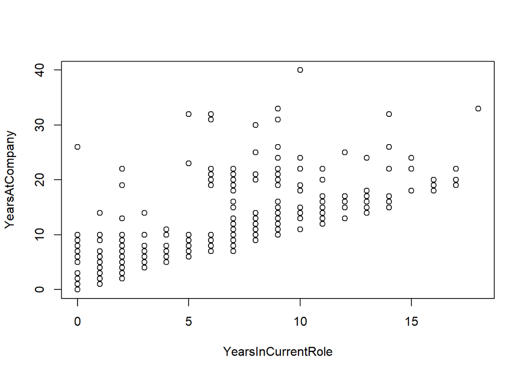

```r
plot(YearsAtCompany ~ YearsInCurrentRole, data = income.df)
```

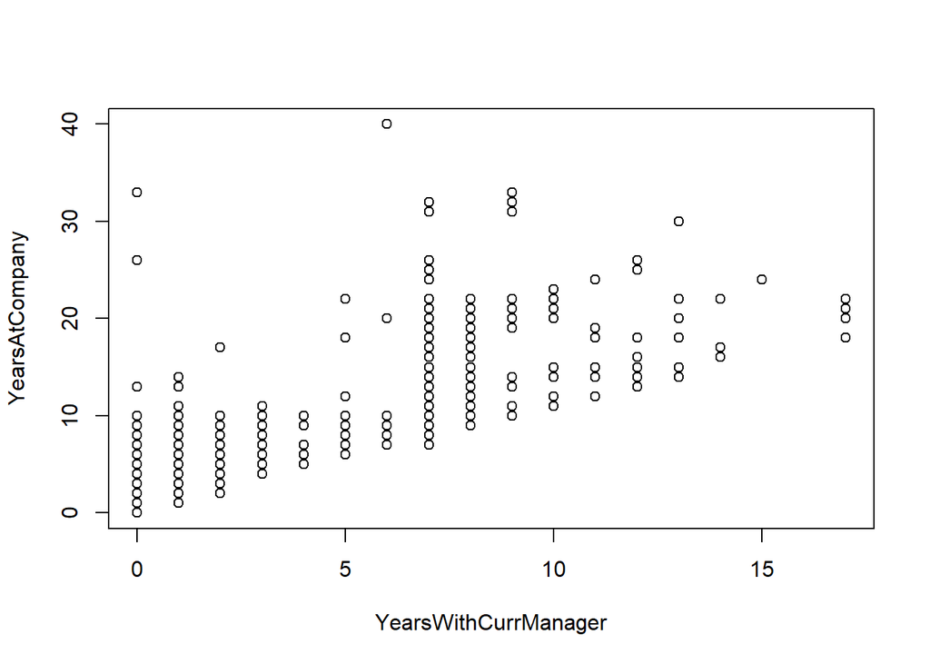

```r
plot(YearsAtCompany ~ YearsWithCurrManager, data = income.df)
```

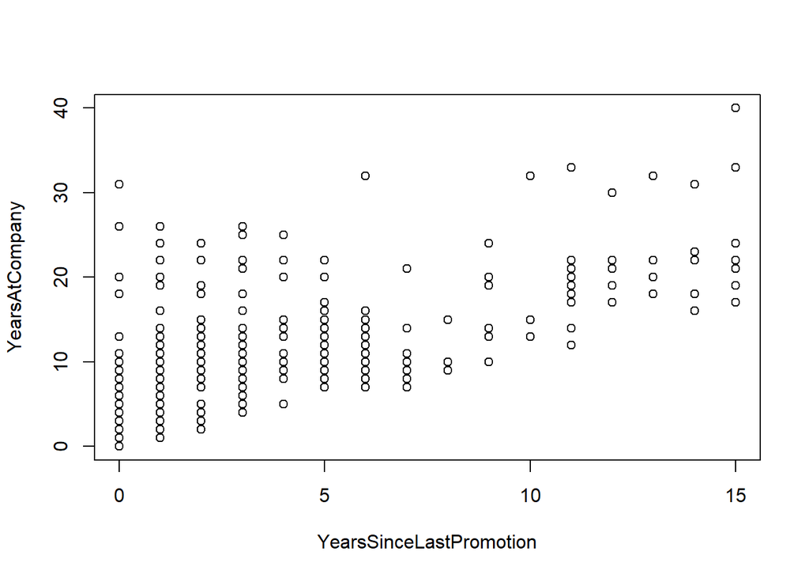

```r
plot(YearsAtCompany ~ YearsSinceLastPromotion, data = income.df)
```

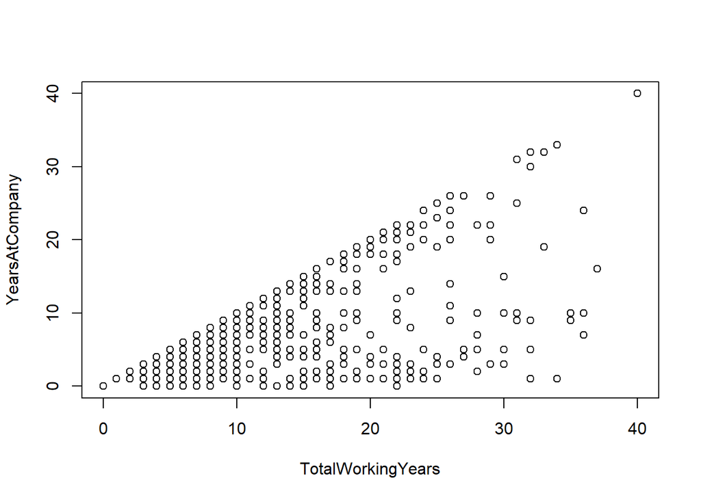

```r
plot(YearsAtCompany ~ TotalWorkingYears, data = income.df)
```

```r
performance.cor <- as.data.frame(cor(cont.income)["PerformanceRating",])
names(performance.cor) <- "Correlation"
performance.cor <- data.frame(Variable=row.names(performance.cor), Correlation = performance.cor)
head(performance.cor)
```

```
##                                        Variable  Correlation
## Age                                         Age -0.041084685
## DailyRate                             DailyRate -0.024072724
## DistanceFromHome               DistanceFromHome  0.033190328
## Education                             Education -0.028051113
## EnvironmentSatisfaction EnvironmentSatisfaction -0.004524833
## HourlyRate                           HourlyRate  0.003182237
```

```r
order.cor <- order(performance.cor$Correlation, decreasing = T)
performance.cor <- performance.cor[order.cor,]
row.names(performance.cor) <- 1:nrow(performance.cor)
performance.cor
```

```
##                    Variable  Correlation
## 1         PerformanceRating  1.000000000
## 2         PercentSalaryHike  0.775053243
## 3          DistanceFromHome  0.033190328
## 4           WorkLifeBalance  0.017234301
## 5            JobInvolvement  0.011688638
## 6        YearsInCurrentRole  0.008802684
## 7                HourlyRate  0.003182237
## 8               MonthlyRate -0.003288565
## 9   EnvironmentSatisfaction -0.004524833
## 10          JobSatisfaction -0.004641900
## 11     YearsWithCurrManager -0.004942028
## 12    TrainingTimesLastYear -0.007174679
## 13         StockOptionLevel -0.016727978
## 14                DailyRate -0.024072724
## 15           YearsAtCompany -0.026617880
## 16                Education -0.028051113
## 17       NumCompaniesWorked -0.029306651
## 18 RelationshipSatisfaction -0.029980063
## 19  YearsSinceLastPromotion -0.036530370
## 20                 JobLevel -0.038696689
## 21                      Age -0.041084685
## 22        TotalWorkingYears -0.041377258
## 23            MonthlyIncome -0.043130996
```

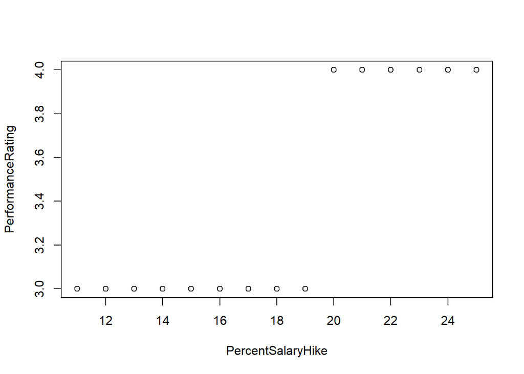

```r
plot(PerformanceRating ~ PercentSalaryHike, data = income.df)
```

job level highly correlated with monthly income and moderately correlated with Total Working Year and Years at Company ##lets remove job level for the model

```r
income.df$JobLevel = NULL

str(income.df)
```

```
## 'data.frame':    870 obs. of  30 variables:
##  $ Age                     : int  32 40 35 32 24 27 41 37 34 34 ...
##  $ Attrition               : Factor w/ 2 levels "No","Yes": 1 1 1 1 1 1 1 1 1 1 ...
##  $ BusinessTravel          : Factor w/ 3 levels "Non-Travel","Travel_Frequently",..: 3 3 2 3 2 2 3 3 3 2 ...
##  $ DailyRate               : int  117 1308 200 801 567 294 1283 309 1333 653 ...
##  $ Department              : Factor w/ 3 levels "Human Resources",..: 3 2 2 3 2 2 2 3 3 2 ...
##  $ DistanceFromHome        : int  13 14 18 1 2 10 5 10 10 10 ...
##  $ Education               : int  4 3 2 4 1 2 5 4 4 4 ...
##  $ EducationField          : Factor w/ 6 levels "Human Resources",..: 2 4 2 3 6 2 4 2 2 6 ...
##  $ EnvironmentSatisfaction : int  2 3 3 3 1 4 2 4 3 4 ...
##  $ Gender                  : Factor w/ 2 levels "Female","Male": 2 2 2 1 1 2 2 1 1 2 ...
##  $ HourlyRate              : int  73 44 60 48 32 32 90 88 87 92 ...
##  $ JobInvolvement          : int  3 2 3 3 3 3 4 2 3 2 ...
##  $ JobRole                 : Factor w/ 9 levels "Healthcare Representative",..: 8 6 5 8 7 5 7 8 9 1 ...
##  $ JobSatisfaction         : int  4 3 4 4 4 1 3 4 3 3 ...
```

[output cut: 16 more lines]

which variables are the most important using entire dataset for glm model?

```r
logic.fit.full <- glm(Attrition ~ ., data = income.df, family = binomial(link="logit"))
summary(logic.fit.full)
```

```
##
## Call:
## glm(formula = Attrition ~ ., family = binomial(link = "logit"),
##     data = income.df)
##
## Deviance Residuals:
##     Min       1Q   Median       3Q      Max
## -1.6072  -0.4419  -0.2148  -0.0583   3.2595
##
## Coefficients:
##                                    Estimate Std. Error z value Pr(>|z|)
## (Intercept)                      -1.122e+01  7.390e+02  -0.015 0.987882
## Age                              -3.071e-02  1.873e-02  -1.639 0.101116
## BusinessTravelTravel_Frequently   1.583e+00  5.218e-01   3.033 0.002420
## BusinessTravelTravel_Rarely       8.638e-01  4.606e-01   1.875 0.060756
## DailyRate                        -3.178e-04  3.119e-04  -1.019 0.308266
## DepartmentResearch & Development  1.389e+01  7.390e+02   0.019 0.985005
## DepartmentSales                   1.382e+01  7.390e+02   0.019 0.985077
## DistanceFromHome                  5.043e-02  1.492e-02   3.380 0.000725
## Education                        -3.413e-02  1.215e-01  -0.281 0.778780
## EducationFieldLife Sciences      -1.256e+00  1.218e+00  -1.031 0.302446
## EducationFieldMarketing          -1.219e+00  1.277e+00  -0.955 0.339454
## EducationFieldMedical            -1.231e+00  1.216e+00  -1.012 0.311318
## EducationFieldOther              -9.991e-01  1.277e+00  -0.782 0.434103
## EducationFieldTechnical Degree   -6.656e-01  1.250e+00  -0.532 0.594542
## EnvironmentSatisfaction          -3.538e-01  1.165e-01  -3.036 0.002394
## GenderMale                        2.051e-01  2.504e-01   0.819 0.412725
## HourlyRate                        1.162e-02  6.331e-03   1.836 0.066385
## JobInvolvement                   -7.907e-01  1.727e-01  -4.578 4.69e-06
## JobRoleHuman Resources            1.498e+01  7.390e+02   0.020 0.983829
## JobRoleLaboratory Technician      1.105e+00  5.856e-01   1.888 0.059060
## JobRoleManager                   -2.511e-01  1.199e+00  -0.209 0.834123
## JobRoleManufacturing Director    -1.704e+00  8.879e-01  -1.919 0.054986
## JobRoleResearch Director         -2.310e+00  1.410e+00  -1.638 0.101476
## JobRoleResearch Scientist         4.370e-01  5.792e-01   0.755 0.450500
## JobRoleSales Executive            7.201e-01  1.399e+00   0.515 0.606832
## JobRoleSales Representative       2.259e+00  1.462e+00   1.545 0.122356
## JobSatisfaction                  -4.912e-01  1.131e-01  -4.342 1.41e-05
## MaritalStatusMarried              9.384e-01  4.226e-01   2.221 0.026370
## MaritalStatusSingle               1.774e+00  5.175e-01   3.427 0.000609
```

[output cut: 55 more lines]

```
## WorkLifeBalance                  ***
## YearsAtCompany
## YearsInCurrentRole               *
## YearsSinceLastPromotion          ***
## YearsWithCurrManager             *
## ---
## Signif. codes:  0 '***' 0.001 '**' 0.01 '*' 0.05 '.' 0.1 ' ' 1
##
## (Dispersion parameter for binomial family taken to be 1)
##
##     Null deviance: 767.67  on 869  degrees of freedom
## Residual deviance: 467.63  on 826  degrees of freedom
## AIC: 555.63
##
## Number of Fisher Scoring iterations: 15
```

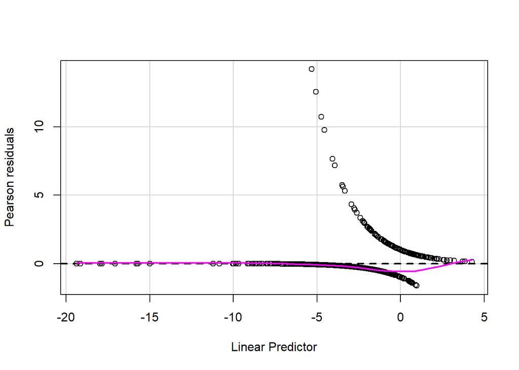

```r
residualPlot(logic.fit.full)
```

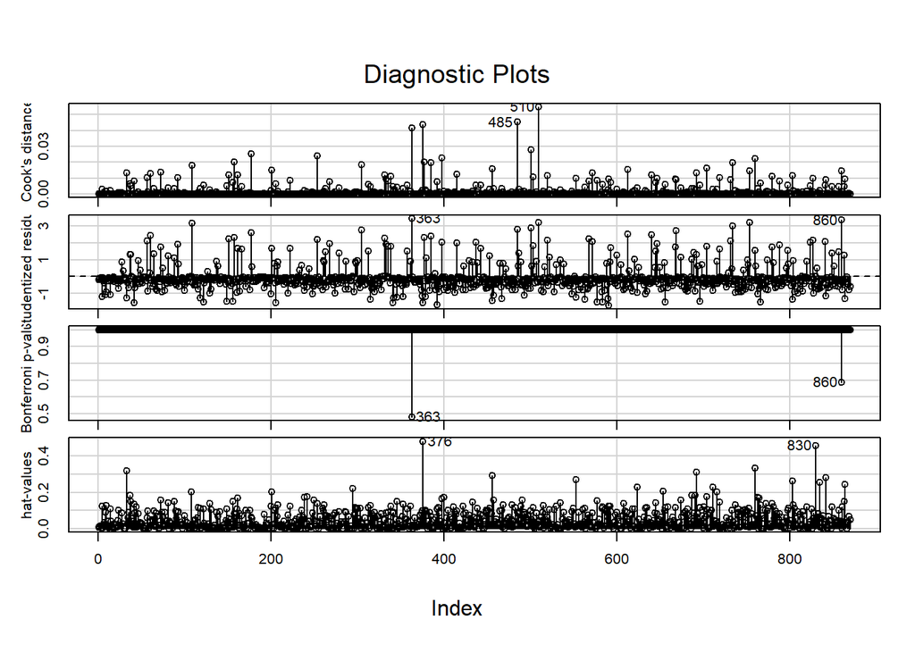

```r
influenceIndexPlot(logic.fit.full)
```

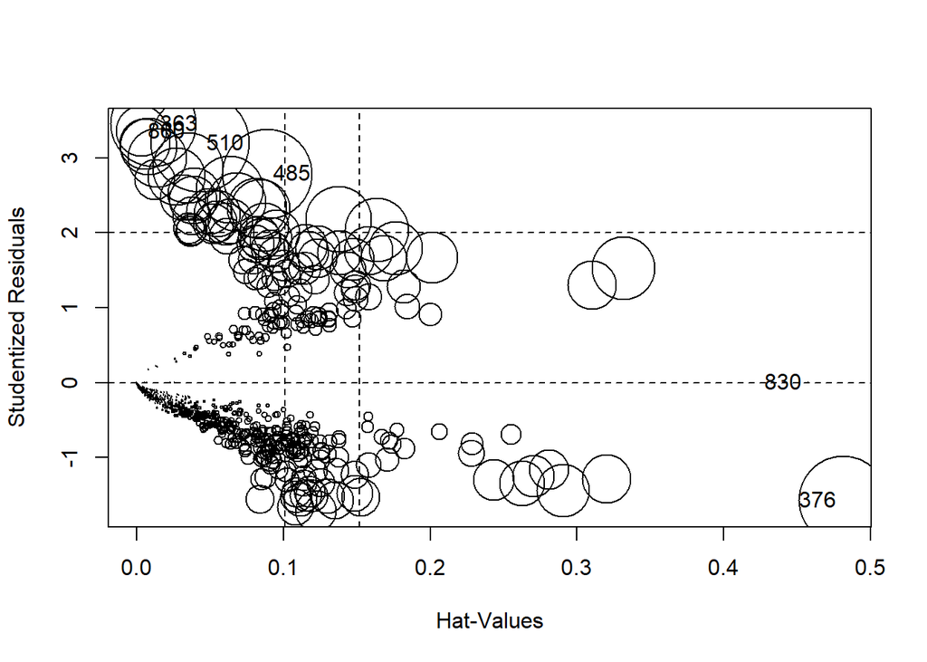

```
##           StudRes         Hat        CookD
## 363  3.4549700017 0.011305576 4.144684e-02
## 376 -1.5717128988 0.481134549 4.395379e-02
## 485  2.7889343076 0.088685419 4.534891e-02
## 510  3.1989679044 0.043177150 5.504383e-02
## 830 -0.0009362672 0.457574828 1.089595e-08
## 860  3.3566848044 0.003178384 1.466727e-02
```

```r
influencePlot(logic.fit.full)
```

Lets check for influential outliers and remove them if they exist and compare to full model

```r
logic.fit.full.no.out <- update(logic.fit.full, subset = c(-363, -376, -485, -510, -830, -860))
compareCoefs(logic.fit.full, logic.fit.full.no.out)
```

```
## Calls:
## 1: glm(formula = Attrition ~ ., family = binomial(link = "logit"),
##   data = income.df)
## 2: glm(formula = Attrition ~ ., family = binomial(link = "logit"),
##   data = income.df, subset = c(-363, -376, -485, -510, -830, -860))
##
##                                    Model 1   Model 2
## (Intercept)                          -11.2     -12.0
## SE                                   739.0    2152.4
##
## Age                                -0.0307   -0.0391
## SE                                  0.0187    0.0197
##
## BusinessTravelTravel_Frequently      1.583     1.835
## SE                                   0.522     0.558
##
## BusinessTravelTravel_Rarely          0.864     0.870
## SE                                   0.461     0.491
##
## DailyRate                        -0.000318 -0.000284
## SE                                0.000312  0.000331
##
## DepartmentResearch & Development      13.9      15.1
## SE                                   739.0    2152.4
##
## DepartmentSales                       13.8      14.2
## SE                                   739.0    2152.4
##
## DistanceFromHome                    0.0504    0.0523
## SE                                  0.0149    0.0160
##
## Education                         -0.03413   0.00411
## SE                                 0.12149   0.12966
##
## EducationFieldLife Sciences          -1.26     -1.21
## SE                                    1.22      1.25
##
## EducationFieldMarketing              -1.22     -1.29
## SE                                    1.28      1.31
##
```

[output cut: 84 more lines]

```
## WorkLifeBalance                     -0.570    -0.641
## SE                                   0.171     0.181
##
## YearsAtCompany                      0.0810   -0.0111
## SE                                  0.0536    0.0695
##
## YearsInCurrentRole                 -0.1307   -0.1417
## SE                                  0.0615    0.0692
##
## YearsSinceLastPromotion             0.2500    0.2937
## SE                                  0.0607    0.0675
##
## YearsWithCurrManager               -0.1589   -0.0787
## SE                                  0.0649    0.0802
##
```

```r
summary(logic.fit.full.no.out)
```

```
##
## Call:
## glm(formula = Attrition ~ ., family = binomial(link = "logit"),
##     data = income.df, subset = c(-363, -376, -485, -510, -830,
##         -860))
##
## Deviance Residuals:
##     Min       1Q   Median       3Q      Max
## -1.6728  -0.4130  -0.1724  -0.0241   3.3803
##
## Coefficients:
##                                    Estimate Std. Error z value Pr(>|z|)
## (Intercept)                      -1.204e+01  2.152e+03  -0.006 0.995536
## Age                              -3.914e-02  1.974e-02  -1.983 0.047364
## BusinessTravelTravel_Frequently   1.835e+00  5.582e-01   3.287 0.001014
## BusinessTravelTravel_Rarely       8.696e-01  4.910e-01   1.771 0.076570
## DailyRate                        -2.842e-04  3.314e-04  -0.858 0.391169
## DepartmentResearch & Development  1.513e+01  2.152e+03   0.007 0.994390
## DepartmentSales                   1.423e+01  2.152e+03   0.007 0.994726
## DistanceFromHome                  5.231e-02  1.599e-02   3.271 0.001071
## Education                         4.107e-03  1.297e-01   0.032 0.974732
## EducationFieldLife Sciences      -1.209e+00  1.251e+00  -0.966 0.333835
## EducationFieldMarketing          -1.293e+00  1.314e+00  -0.984 0.325082
## EducationFieldMedical            -1.214e+00  1.249e+00  -0.973 0.330735
## EducationFieldOther              -1.105e+00  1.312e+00  -0.842 0.399610
## EducationFieldTechnical Degree   -7.808e-01  1.294e+00  -0.603 0.546214
## EnvironmentSatisfaction          -3.473e-01  1.239e-01  -2.803 0.005057
## GenderMale                        4.381e-01  2.692e-01   1.628 0.103617
## HourlyRate                        1.360e-02  6.757e-03   2.012 0.044210
## JobInvolvement                   -8.782e-01  1.841e-01  -4.770 1.84e-06
## JobRoleHuman Resources            1.675e+01  2.152e+03   0.008 0.993792
## JobRoleLaboratory Technician      1.459e+00  6.495e-01   2.246 0.024727
## JobRoleManager                    3.839e-01  1.298e+00   0.296 0.767450
## JobRoleManufacturing Director    -1.390e+00  9.500e-01  -1.464 0.143326
## JobRoleResearch Director         -1.550e+01  7.715e+02  -0.020 0.983976
## JobRoleResearch Scientist         7.715e-01  6.414e-01   1.203 0.229065
## JobRoleSales Executive            2.024e+00  1.636e+00   1.237 0.216093
## JobRoleSales Representative       3.488e+00  1.693e+00   2.060 0.039385
## JobSatisfaction                  -5.935e-01  1.217e-01  -4.875 1.09e-06
## MaritalStatusMarried              8.990e-01  4.402e-01   2.042 0.041128
```

[output cut: 56 more lines]

```
## WorkLifeBalance                  ***
## YearsAtCompany
## YearsInCurrentRole               *
## YearsSinceLastPromotion          ***
## YearsWithCurrManager
## ---
## Signif. codes:  0 '***' 0.001 '**' 0.01 '*' 0.05 '.' 0.1 ' ' 1
##
## (Dispersion parameter for binomial family taken to be 1)
##
##     Null deviance: 752.28  on 863  degrees of freedom
## Residual deviance: 421.73  on 820  degrees of freedom
## AIC: 509.73
##
## Number of Fisher Scoring iterations: 17
```

```r
View(income.df[c(363, 376, 485, 510, 830, 860),])
```

Which variables are most important to our full model?

```r
full.variable.imp <- varImp(logic.fit.full)
names(full.variable.imp) <- "Importance"
full.variable.imp$Variable <- row.names(full.variable.imp)
full.variable.imp <- full.variable.imp[order(full.variable.imp$Importance, decreasing = T),]
row.names(full.variable.imp) <- 1:nrow(full.variable.imp)
full.variable.imp <- full.variable.imp[,c(2,1)]
full.variable.imp
```

```
##                            Variable Importance
## 1                       OverTimeYes 7.74520538
## 2                    JobInvolvement 4.57819897
## 3                NumCompaniesWorked 4.49852166
## 4                   JobSatisfaction 4.34228471
## 5           YearsSinceLastPromotion 4.11506424
## 6               MaritalStatusSingle 3.42742695
## 7                  DistanceFromHome 3.38000697
## 8                   WorkLifeBalance 3.34070133
## 9           EnvironmentSatisfaction 3.03643753
## 10  BusinessTravelTravel_Frequently 3.03322444
## 11            TrainingTimesLastYear 2.75210987
## 12                TotalWorkingYears 2.57956734
## 13             YearsWithCurrManager 2.44735545
## 14         RelationshipSatisfaction 2.36432339
```

[output cut: 29 more lines]

lets use only the statistically significant variables and build a reduced model

```r
logic.fit.reduced <- glm(Attrition ~ BusinessTravel + DistanceFromHome + EnvironmentSatisfaction + JobInvolvement +
                           JobRole + JobSatisfaction + MaritalStatus + NumCompaniesWorked + OverTime + RelationshipSatisfaction +
                           TotalWorkingYears + TrainingTimesLastYear + WorkLifeBalance + YearsInCurrentRole + YearsSinceLastPromotion + YearsWithCurrManager,
                         data = income.df, family = binomial(link = "logit"))
summary(logic.fit.reduced)
```

```
##
## Call:
## glm(formula = Attrition ~ BusinessTravel + DistanceFromHome +
##     EnvironmentSatisfaction + JobInvolvement + JobRole + JobSatisfaction +
##     MaritalStatus + NumCompaniesWorked + OverTime + RelationshipSatisfaction +
##     TotalWorkingYears + TrainingTimesLastYear + WorkLifeBalance +
##     YearsInCurrentRole + YearsSinceLastPromotion + YearsWithCurrManager,
##     family = binomial(link = "logit"), data = income.df)
##
## Deviance Residuals:
##     Min       1Q   Median       3Q      Max
## -1.8016  -0.4685  -0.2284  -0.0738   3.3181
##
## Coefficients:
##                                 Estimate Std. Error z value Pr(>|z|)
## (Intercept)                      2.31295    1.09252   2.117  0.03425 *
## BusinessTravelTravel_Frequently  1.49408    0.49450   3.021  0.00252 **
## BusinessTravelTravel_Rarely      0.76526    0.43707   1.751  0.07997 .
## DistanceFromHome                 0.04498    0.01429   3.149  0.00164 **
## EnvironmentSatisfaction         -0.31880    0.11048  -2.886  0.00391 **
## JobInvolvement                  -0.82126    0.16486  -4.982 6.31e-07 ***
## JobRoleHuman Resources           1.23523    0.73077   1.690  0.09097 .
## JobRoleLaboratory Technician     0.73844    0.52340   1.411  0.15829
## JobRoleManager                   0.50522    0.77443   0.652  0.51416
## JobRoleManufacturing Director   -1.73870    0.87345  -1.991  0.04652 *
## JobRoleResearch Director        -1.52282    1.20926  -1.259  0.20792
## JobRoleResearch Scientist        0.13150    0.51835   0.254  0.79974
## JobRoleSales Executive           0.54216    0.50395   1.076  0.28200
## JobRoleSales Representative      1.72648    0.59292   2.912  0.00359 **
## JobSatisfaction                 -0.50609    0.10921  -4.634 3.58e-06 ***
## MaritalStatusMarried             0.94844    0.38629   2.455  0.01408 *
## MaritalStatusSingle              1.87505    0.39156   4.789 1.68e-06 ***
## NumCompaniesWorked               0.19835    0.05080   3.904 9.45e-05 ***
## OverTimeYes                      1.91851    0.25087   7.647 2.05e-14 ***
## RelationshipSatisfaction        -0.24579    0.10557  -2.328  0.01990 *
## TotalWorkingYears               -0.09871    0.03010  -3.280  0.00104 **
## TrainingTimesLastYear           -0.27261    0.10093  -2.701  0.00691 **
## WorkLifeBalance                 -0.53737    0.16335  -3.290  0.00100 **
## YearsInCurrentRole              -0.08311    0.05469  -1.520  0.12859
## YearsSinceLastPromotion          0.27339    0.05497   4.974 6.56e-07 ***
## YearsWithCurrManager            -0.10699    0.05778  -1.852  0.06409 .
## ---
## Signif. codes:  0 '***' 0.001 '**' 0.01 '*' 0.05 '.' 0.1 ' ' 1
##
## (Dispersion parameter for binomial family taken to be 1)
##
##     Null deviance: 767.67  on 869  degrees of freedom
## Residual deviance: 486.47  on 844  degrees of freedom
## AIC: 538.47
##
## Number of Fisher Scoring iterations: 7
```

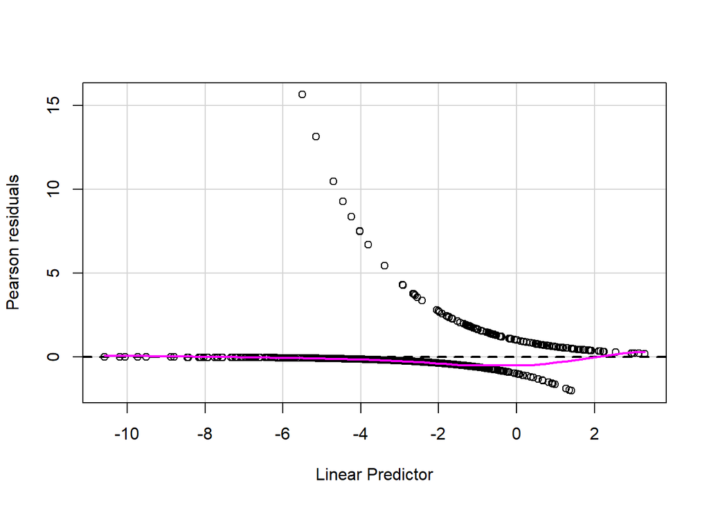

```r
residualPlot(logic.fit.reduced)
```

```r
logic.fit.reduced2 <- glm(Attrition ~ BusinessTravel + DistanceFromHome + EnvironmentSatisfaction + JobInvolvement +
                           JobSatisfaction + MaritalStatus + NumCompaniesWorked + OverTime + RelationshipSatisfaction +
                           TotalWorkingYears + TrainingTimesLastYear + WorkLifeBalance + YearsSinceLastPromotion,
                         data = income.df, family = binomial(link = "logit"))
summary(logic.fit.reduced2)
```

```
##
## Call:
## glm(formula = Attrition ~ BusinessTravel + DistanceFromHome +
##     EnvironmentSatisfaction + JobInvolvement + JobSatisfaction +
##     MaritalStatus + NumCompaniesWorked + OverTime + RelationshipSatisfaction +
##     TotalWorkingYears + TrainingTimesLastYear + WorkLifeBalance +
##     YearsSinceLastPromotion, family = binomial(link = "logit"),
##     data = income.df)
##
## Deviance Residuals:
##     Min       1Q   Median       3Q      Max
## -1.8018  -0.5286  -0.2804  -0.1158   3.6409
##
## Coefficients:
##                                 Estimate Std. Error z value Pr(>|z|)
## (Intercept)                      2.66260    0.93097   2.860  0.00424 **
## BusinessTravelTravel_Frequently  1.50055    0.47966   3.128  0.00176 **
## BusinessTravelTravel_Rarely      0.80082    0.42939   1.865  0.06218 .
## DistanceFromHome                 0.04132    0.01341   3.081  0.00207 **
## EnvironmentSatisfaction         -0.30363    0.10312  -2.944  0.00324 **
## JobInvolvement                  -0.84086    0.15794  -5.324 1.02e-07 ***
## JobSatisfaction                 -0.49291    0.10322  -4.775 1.79e-06 ***
## MaritalStatusMarried             0.89461    0.36822   2.430  0.01512 *
## MaritalStatusSingle              1.86116    0.37474   4.966 6.82e-07 ***
## NumCompaniesWorked               0.21190    0.04595   4.611 4.00e-06 ***
## OverTimeYes                      1.73437    0.23159   7.489 6.93e-14 ***
## RelationshipSatisfaction        -0.24622    0.10036  -2.453  0.01416 *
## TotalWorkingYears               -0.16655    0.02533  -6.576 4.83e-11 ***
## TrainingTimesLastYear           -0.20898    0.09294  -2.249  0.02454 *
## WorkLifeBalance                 -0.49289    0.15153  -3.253  0.00114 **
## YearsSinceLastPromotion          0.18808    0.04526   4.155 3.25e-05 ***
## ---
## Signif. codes:  0 '***' 0.001 '**' 0.01 '*' 0.05 '.' 0.1 ' ' 1
##
## (Dispersion parameter for binomial family taken to be 1)
##
##     Null deviance: 767.67  on 869  degrees of freedom
## Residual deviance: 532.88  on 854  degrees of freedom
## AIC: 564.88
##
## Number of Fisher Scoring iterations: 6
```

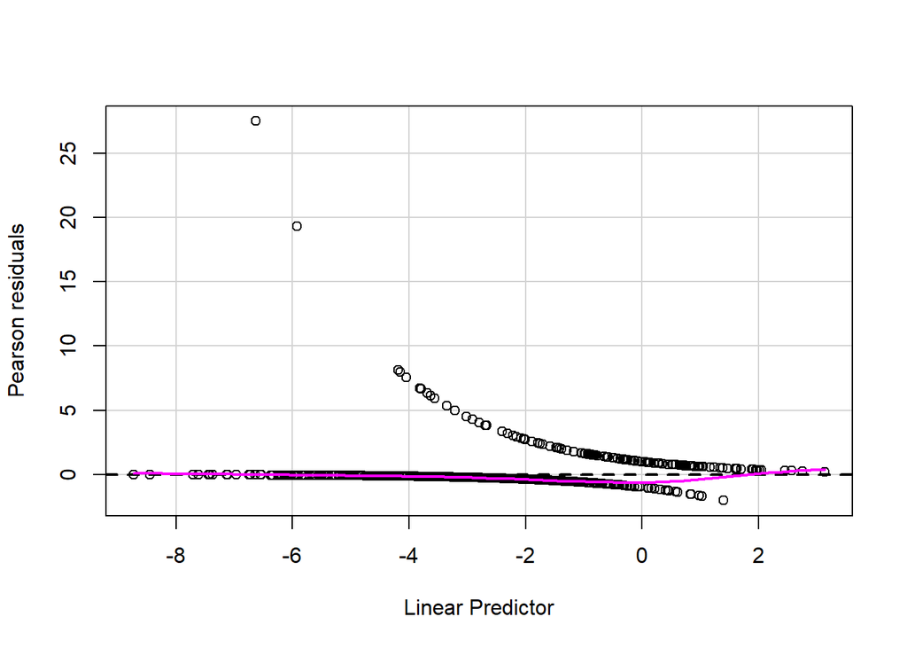

```r
residualPlot(logic.fit.reduced2)
```

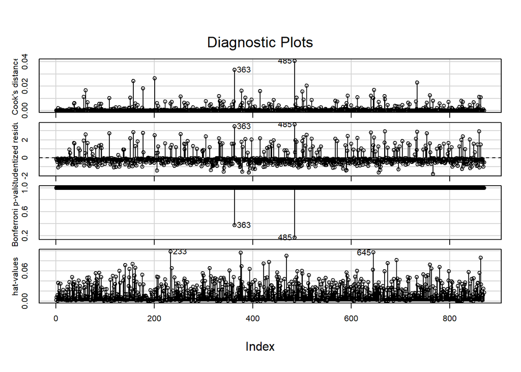

```r
influenceIndexPlot(logic.fit.reduced2)
```

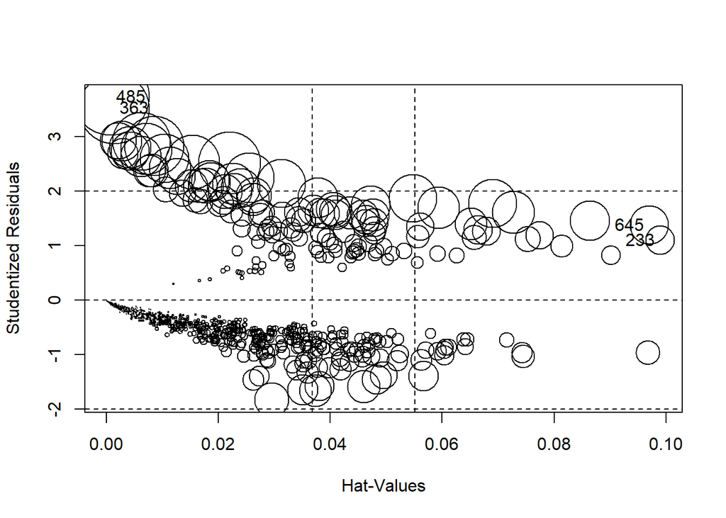

```
##      StudRes          Hat      CookD
## 233 1.093695 0.0989361547 0.00567909
## 363 3.519234 0.0014357466 0.03356970
## 485 3.729429 0.0008638128 0.04082882
## 645 1.374576 0.0969969724 0.01031498
```

```r
influencePlot(logic.fit.reduced2)
```

once again, lets take a look at influential outliers and compare a outlier-less model to the oulier-included model

```r
View(income.df[c(233,363,485,645),])

logic.fit.reduced.no.out <- update(logic.fit.reduced2, subset = c(-233, -363, -485, -645))
compareCoefs(logic.fit.reduced2, logic.fit.reduced.no.out)
```

```
## Calls:
## 1: glm(formula = Attrition ~ BusinessTravel + DistanceFromHome +
##   EnvironmentSatisfaction + JobInvolvement + JobSatisfaction +
##   MaritalStatus + NumCompaniesWorked + OverTime +
##   RelationshipSatisfaction + TotalWorkingYears + TrainingTimesLastYear +
##   WorkLifeBalance + YearsSinceLastPromotion, family = binomial(link =
##   "logit"), data = income.df)
## 2: glm(formula = Attrition ~ BusinessTravel + DistanceFromHome +
##   EnvironmentSatisfaction + JobInvolvement + JobSatisfaction +
##   MaritalStatus + NumCompaniesWorked + OverTime +
##   RelationshipSatisfaction + TotalWorkingYears + TrainingTimesLastYear +
##   WorkLifeBalance + YearsSinceLastPromotion, family = binomial(link =
##   "logit"), data = income.df, subset = c(-233, -363, -485, -645))
##
##                                 Model 1 Model 2
## (Intercept)                       2.663   2.784
## SE                                0.931   1.001
##
## BusinessTravelTravel_Frequently   1.501   1.677
## SE                                0.480   0.508
##
## BusinessTravelTravel_Rarely       0.801   0.915
## SE                                0.429   0.456
##
## DistanceFromHome                 0.0413  0.0446
## SE                               0.0134  0.0139
##
## EnvironmentSatisfaction          -0.304  -0.322
## SE                                0.103   0.107
##
## JobInvolvement                   -0.841  -0.819
## SE                                0.158   0.164
##
## JobSatisfaction                  -0.493  -0.542
## SE                                0.103   0.107
##
## MaritalStatusMarried              0.895   0.904
## SE                                0.368   0.384
##
## MaritalStatusSingle               1.861   1.966
```

[output cut: 8 more lines]

```
## RelationshipSatisfaction         -0.246  -0.291
## SE                                0.100   0.104
##
## TotalWorkingYears               -0.1666 -0.1953
## SE                               0.0253  0.0277
##
## TrainingTimesLastYear           -0.2090 -0.2246
## SE                               0.0929  0.0959
##
## WorkLifeBalance                  -0.493  -0.473
## SE                                0.152   0.159
##
## YearsSinceLastPromotion          0.1881  0.1891
## SE                               0.0453  0.0491
##
```

```r
summary(logic.fit.full.no.out)
```

```
##
## Call:
## glm(formula = Attrition ~ ., family = binomial(link = "logit"),
##     data = income.df, subset = c(-363, -376, -485, -510, -830,
##         -860))
##
## Deviance Residuals:
##     Min       1Q   Median       3Q      Max
## -1.6728  -0.4130  -0.1724  -0.0241   3.3803
##
## Coefficients:
##                                    Estimate Std. Error z value Pr(>|z|)
## (Intercept)                      -1.204e+01  2.152e+03  -0.006 0.995536
## Age                              -3.914e-02  1.974e-02  -1.983 0.047364
## BusinessTravelTravel_Frequently   1.835e+00  5.582e-01   3.287 0.001014
## BusinessTravelTravel_Rarely       8.696e-01  4.910e-01   1.771 0.076570
## DailyRate                        -2.842e-04  3.314e-04  -0.858 0.391169
## DepartmentResearch & Development  1.513e+01  2.152e+03   0.007 0.994390
## DepartmentSales                   1.423e+01  2.152e+03   0.007 0.994726
## DistanceFromHome                  5.231e-02  1.599e-02   3.271 0.001071
## Education                         4.107e-03  1.297e-01   0.032 0.974732
## EducationFieldLife Sciences      -1.209e+00  1.251e+00  -0.966 0.333835
## EducationFieldMarketing          -1.293e+00  1.314e+00  -0.984 0.325082
## EducationFieldMedical            -1.214e+00  1.249e+00  -0.973 0.330735
## EducationFieldOther              -1.105e+00  1.312e+00  -0.842 0.399610
## EducationFieldTechnical Degree   -7.808e-01  1.294e+00  -0.603 0.546214
## EnvironmentSatisfaction          -3.473e-01  1.239e-01  -2.803 0.005057
## GenderMale                        4.381e-01  2.692e-01   1.628 0.103617
## HourlyRate                        1.360e-02  6.757e-03   2.012 0.044210
## JobInvolvement                   -8.782e-01  1.841e-01  -4.770 1.84e-06
## JobRoleHuman Resources            1.675e+01  2.152e+03   0.008 0.993792
## JobRoleLaboratory Technician      1.459e+00  6.495e-01   2.246 0.024727
## JobRoleManager                    3.839e-01  1.298e+00   0.296 0.767450
## JobRoleManufacturing Director    -1.390e+00  9.500e-01  -1.464 0.143326
## JobRoleResearch Director         -1.550e+01  7.715e+02  -0.020 0.983976
## JobRoleResearch Scientist         7.715e-01  6.414e-01   1.203 0.229065
## JobRoleSales Executive            2.024e+00  1.636e+00   1.237 0.216093
## JobRoleSales Representative       3.488e+00  1.693e+00   2.060 0.039385
## JobSatisfaction                  -5.935e-01  1.217e-01  -4.875 1.09e-06
## MaritalStatusMarried              8.990e-01  4.402e-01   2.042 0.041128
```

[output cut: 56 more lines]

```
## WorkLifeBalance                  ***
## YearsAtCompany
## YearsInCurrentRole               *
## YearsSinceLastPromotion          ***
## YearsWithCurrManager
## ---
## Signif. codes:  0 '***' 0.001 '**' 0.01 '*' 0.05 '.' 0.1 ' ' 1
##
## (Dispersion parameter for binomial family taken to be 1)
##
##     Null deviance: 752.28  on 863  degrees of freedom
## Residual deviance: 421.73  on 820  degrees of freedom
## AIC: 509.73
##
## Number of Fisher Scoring iterations: 17
```

lets take a look at the most important variables in our reduced model

```r
reduced.variable.imp2 <- varImp(logic.fit.reduced2)
names(reduced.variable.imp2) <- "Importance"
reduced.variable.imp2$Variable <- row.names(reduced.variable.imp2)
reduced.variable.imp2 <- reduced.variable.imp2[order(reduced.variable.imp2$Importance, decreasing = T),]
row.names(reduced.variable.imp2) <- 1:nrow(reduced.variable.imp2)
reduced.variable.imp2 <- reduced.variable.imp2[,c(2,1)]
reduced.variable.imp2
```

```
##                           Variable Importance
## 1                      OverTimeYes   7.489110
## 2                TotalWorkingYears   6.575952
## 3                   JobInvolvement   5.323912
## 4              MaritalStatusSingle   4.966463
## 5                  JobSatisfaction   4.775366
## 6               NumCompaniesWorked   4.611244
## 7          YearsSinceLastPromotion   4.155198
## 8                  WorkLifeBalance   3.252728
## 9  BusinessTravelTravel_Frequently   3.128340
## 10                DistanceFromHome   3.080524
## 11         EnvironmentSatisfaction   2.944307
## 12        RelationshipSatisfaction   2.453248
## 13            MaritalStatusMarried   2.429571
## 14           TrainingTimesLastYear   2.248623
## 15     BusinessTravelTravel_Rarely   1.865024
```

# LETS TEST OUR MODELS WITH CROSS VALIDATION

Building test and training datasets

```r
income.no.attrition <- income.df[income.df$Attrition == "No",]
income.yes.attrition <- income.df[income.df$Attrition == "Yes",]

set.seed(1234)
index.no <- sample(1:nrow(income.no.attrition), size = nrow(income.no.attrition) * 0.7)
index.yes <- sample(1:nrow(income.yes.attrition), size = nrow(income.yes.attrition) * 0.7)

test.no.attrition <- income.no.attrition[-index.no,]
train.no.attrition <- income.no.attrition[index.no,]

test.yes.attrition <- income.yes.attrition[-index.yes,]
train.yes.attrition <- income.yes.attrition[index.yes,]

nrow(test.no.attrition) + nrow(train.no.attrition)
```

```
## [1] 730
```

```r
nrow(income.no.attrition)
```

```
## [1] 730
```

```r
nrow(test.yes.attrition) + nrow(train.yes.attrition)
```

```
## [1] 140
```

```r
nrow(income.yes.attrition)
```

```
## [1] 140
```

```r
test.income <- rbind(test.no.attrition, test.yes.attrition)
train.income <- rbind(train.no.attrition, train.yes.attrition)
```

logistic regression full

```r
lr.model.full <- glm(Attrition ~ ., data = train.income, family = binomial(link="logit"))
summary(lr.model.full)
```

```
##
## Call:
## glm(formula = Attrition ~ ., family = binomial(link = "logit"),
##     data = train.income)
##
## Deviance Residuals:
##      Min        1Q    Median        3Q       Max
## -1.83916  -0.40392  -0.16476  -0.02753   3.07892
##
## Coefficients:
##                                    Estimate Std. Error z value Pr(>|z|)
## (Intercept)                      -1.066e+01  1.303e+03  -0.008 0.993471
## Age                              -2.665e-02  2.338e-02  -1.140 0.254273
## BusinessTravelTravel_Frequently   2.329e+00  8.016e-01   2.906 0.003661
## BusinessTravelTravel_Rarely       1.519e+00  7.455e-01   2.037 0.041639
## DailyRate                        -3.660e-05  3.935e-04  -0.093 0.925894
## DepartmentResearch & Development  1.397e+01  1.303e+03   0.011 0.991443
## DepartmentSales                  -5.332e-01  1.562e+03   0.000 0.999728
## DistanceFromHome                  6.311e-02  1.886e-02   3.346 0.000821
## Education                         1.305e-02  1.514e-01   0.086 0.931348
## EducationFieldLife Sciences      -2.313e+00  1.543e+00  -1.499 0.133825
## EducationFieldMarketing          -2.581e+00  1.612e+00  -1.601 0.109384
## EducationFieldMedical            -2.078e+00  1.548e+00  -1.342 0.179463
## EducationFieldOther              -1.943e+00  1.606e+00  -1.210 0.226454
## EducationFieldTechnical Degree   -1.505e+00  1.556e+00  -0.967 0.333642
## EnvironmentSatisfaction          -4.171e-01  1.536e-01  -2.714 0.006640
## GenderMale                       -2.917e-01  3.191e-01  -0.914 0.360671
## HourlyRate                        1.212e-02  8.152e-03   1.487 0.136917
## JobInvolvement                   -8.148e-01  2.261e-01  -3.603 0.000314
## JobRoleHuman Resources            1.402e+01  1.303e+03   0.011 0.991415
## JobRoleLaboratory Technician      5.238e-01  7.491e-01   0.699 0.484432
## JobRoleManager                   -1.354e+00  1.588e+00  -0.853 0.393741
## JobRoleManufacturing Director    -2.371e+00  1.189e+00  -1.995 0.046054
## JobRoleResearch Director         -2.122e+00  1.500e+00  -1.415 0.157121
## JobRoleResearch Scientist         7.636e-02  7.503e-01   0.102 0.918933
## JobRoleSales Executive            1.536e+01  8.614e+02   0.018 0.985778
## JobRoleSales Representative       1.673e+01  8.614e+02   0.019 0.984503
## JobSatisfaction                  -6.202e-01  1.516e-01  -4.090 4.32e-05
## MaritalStatusMarried              1.040e+00  5.231e-01   1.989 0.046706
## MaritalStatusSingle               1.244e+00  6.242e-01   1.993 0.046212
```

[output cut: 55 more lines]

```
## WorkLifeBalance                  **
## YearsAtCompany
## YearsInCurrentRole
## YearsSinceLastPromotion          ***
## YearsWithCurrManager             *
## ---
## Signif. codes:  0 '***' 0.001 '**' 0.01 '*' 0.05 '.' 0.1 ' ' 1
##
## (Dispersion parameter for binomial family taken to be 1)
##
##     Null deviance: 537.02  on 607  degrees of freedom
## Residual deviance: 301.50  on 564  degrees of freedom
## AIC: 389.5
##
## Number of Fisher Scoring iterations: 16
```

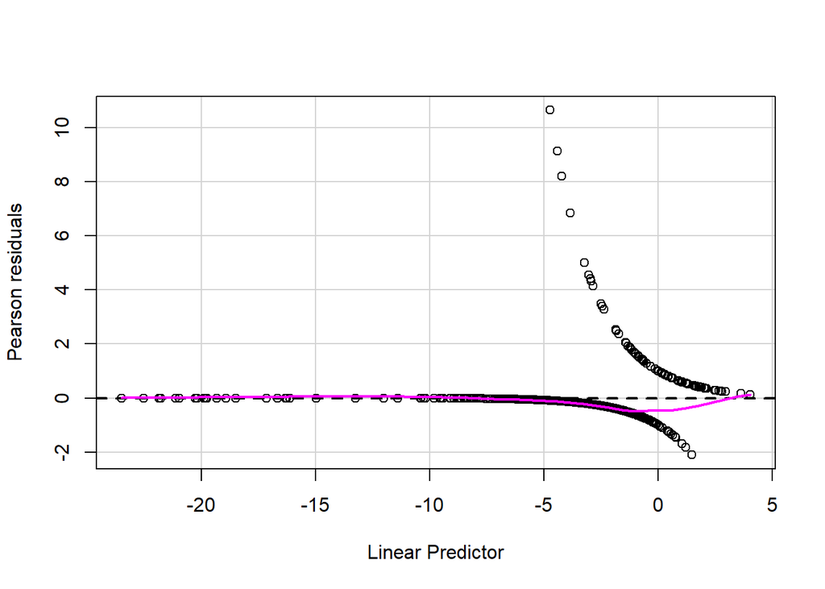

```r
residualPlot(lr.model.full)
```

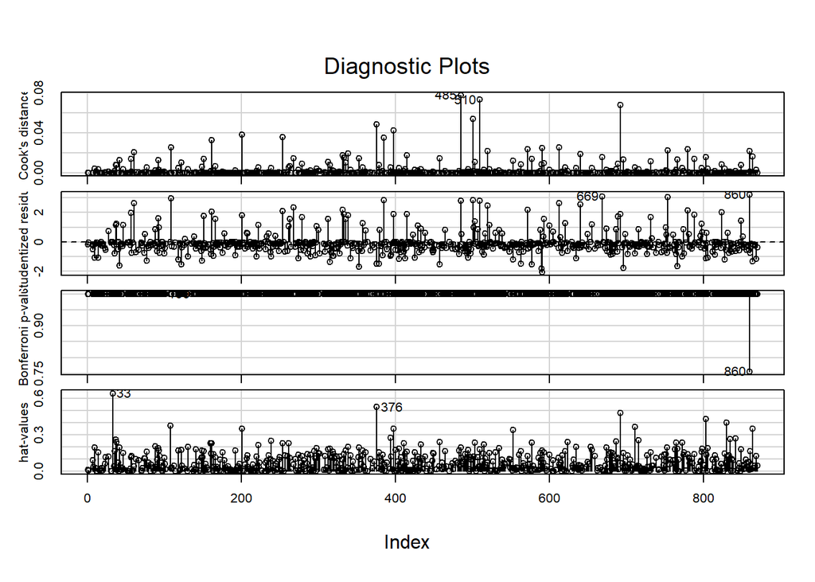

```r
influenceIndexPlot(lr.model.full)
```

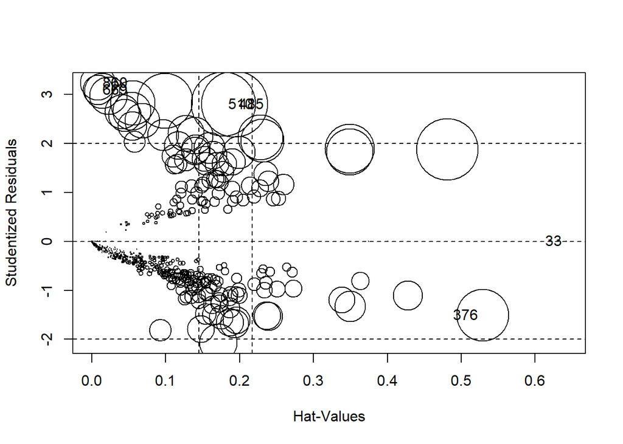

```
##         StudRes         Hat        CookD
## 33  -0.00109949 0.642352525 3.634640e-08
## 376 -1.50867834 0.528860358 4.828982e-02
## 510  2.79551764 0.178504145 7.339815e-02
## 860  3.22879733 0.008266234 2.166486e-02
## 669  3.09186305 0.008166997 1.574648e-02
## 485  2.79755256 0.193077033 7.789326e-02
```

```r
influencePlot(lr.model.full)
```

```r
lr.full.variable.imp <- varImp(lr.model.full)
names(lr.full.variable.imp) <- "Importance"
lr.full.variable.imp$Variable <- row.names(lr.full.variable.imp)
lr.full.variable.imp <- lr.full.variable.imp[order(lr.full.variable.imp$Importance, decreasing = T),]
row.names(lr.full.variable.imp) <- 1:nrow(lr.full.variable.imp)
lr.full.variable.imp <- lr.full.variable.imp[,c(2,1)]
lr.full.variable.imp
```

```
##                            Variable   Importance
## 1                       OverTimeYes 6.9018080196
## 2                   JobSatisfaction 4.0898062203
## 3           YearsSinceLastPromotion 3.6362094058
## 4                    JobInvolvement 3.6034054318
## 5                  DistanceFromHome 3.3455393235
## 6                   WorkLifeBalance 3.2376447023
## 7   BusinessTravelTravel_Frequently 2.9060084537
## 8             TrainingTimesLastYear 2.7857688756
## 9                NumCompaniesWorked 2.7338198073
## 10          EnvironmentSatisfaction 2.7143551744
## 11             YearsWithCurrManager 2.3994435083
## 12                TotalWorkingYears 2.1867908881
## 13      BusinessTravelTravel_Rarely 2.0371094232
## 14    JobRoleManufacturing Director 1.9948988789
```

[output cut: 29 more lines]

logistic regression reduced

```r
lr.model.reduced <- glm(Attrition ~ BusinessTravel + DistanceFromHome + EnvironmentSatisfaction + JobInvolvement +
                            JobSatisfaction + MaritalStatus + NumCompaniesWorked + OverTime + RelationshipSatisfaction +
                            TotalWorkingYears + TrainingTimesLastYear + YearsSinceLastPromotion,
                          data = train.income, family = binomial(link = "logit"))
summary(lr.model.reduced)
```

```
##
## Call:
## glm(formula = Attrition ~ BusinessTravel + DistanceFromHome +
##     EnvironmentSatisfaction + JobInvolvement + JobSatisfaction +
##     MaritalStatus + NumCompaniesWorked + OverTime + RelationshipSatisfaction +
##     TotalWorkingYears + TrainingTimesLastYear + YearsSinceLastPromotion,
##     family = binomial(link = "logit"), data = train.income)
##
## Deviance Residuals:
##     Min       1Q   Median       3Q      Max
## -1.8505  -0.5110  -0.2676  -0.1021   3.8406
##
## Coefficients:
##                                 Estimate Std. Error z value Pr(>|z|)
## (Intercept)                      1.48222    1.10500   1.341 0.179799
## BusinessTravelTravel_Frequently  2.20994    0.72394   3.053 0.002268 **
## BusinessTravelTravel_Rarely      1.32796    0.67194   1.976 0.048121 *
## DistanceFromHome                 0.04675    0.01578   2.963 0.003051 **
## EnvironmentSatisfaction         -0.34447    0.12358  -2.787 0.005314 **
## JobInvolvement                  -0.81931    0.19501  -4.201 2.65e-05 ***
## JobSatisfaction                 -0.57818    0.12951  -4.464 8.03e-06 ***
## MaritalStatusMarried             0.98938    0.44107   2.243 0.024888 *
## MaritalStatusSingle              1.53587    0.45242   3.395 0.000687 ***
## NumCompaniesWorked               0.16901    0.05628   3.003 0.002673 **
## OverTimeYes                      1.87272    0.28323   6.612 3.79e-11 ***
## RelationshipSatisfaction        -0.26647    0.12086  -2.205 0.027469 *
## TotalWorkingYears               -0.18195    0.03213  -5.663 1.48e-08 ***
## TrainingTimesLastYear           -0.26063    0.11196  -2.328 0.019919 *
## YearsSinceLastPromotion          0.19042    0.05602   3.399 0.000677 ***
## ---
## Signif. codes:  0 '***' 0.001 '**' 0.01 '*' 0.05 '.' 0.1 ' ' 1
##
## (Dispersion parameter for binomial family taken to be 1)
##
##     Null deviance: 537.02  on 607  degrees of freedom
## Residual deviance: 367.77  on 593  degrees of freedom
## AIC: 397.77
##
## Number of Fisher Scoring iterations: 6
```

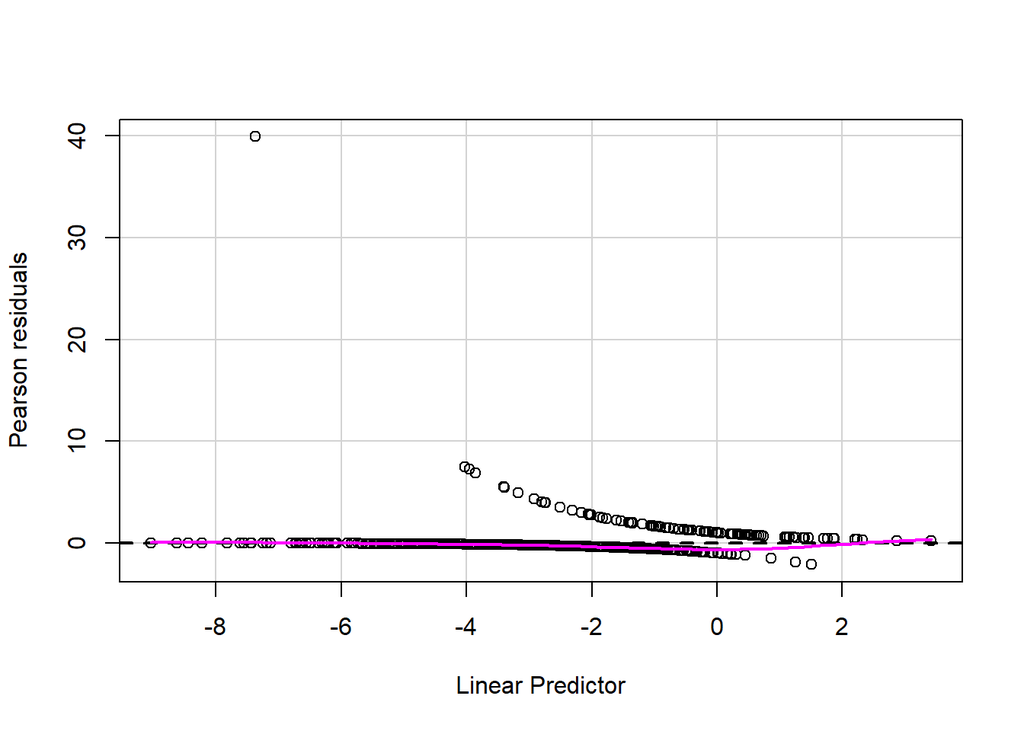

```r
par(mfrow = c(1,1))
residualPlot(lr.model.reduced)
```

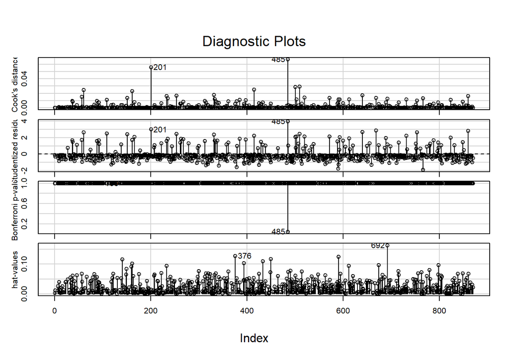

```r
influenceIndexPlot(lr.model.reduced)
```

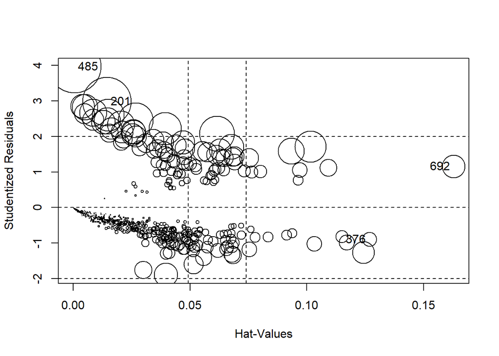

```
##        StudRes          Hat       CookD
## 376 -0.8980793 0.1268572712 0.004977645
## 692  1.1563726 0.1629075741 0.012469715
## 485  3.9687392 0.0006273568 0.066773054
## 201  2.9843272 0.0145107360 0.055691366
```

```r
influencePlot(lr.model.reduced)
```

```r
lr.reduced.variable.imp <- varImp(lr.model.reduced)
names(lr.reduced.variable.imp) <- "Importance"
lr.reduced.variable.imp$Variable <- row.names(lr.reduced.variable.imp)
lr.reduced.variable.imp <- lr.reduced.variable.imp[order(lr.reduced.variable.imp$Importance, decreasing = T),]
row.names(lr.reduced.variable.imp) <- 1:nrow(lr.reduced.variable.imp)
lr.reduced.variable.imp <- lr.reduced.variable.imp[,c(2,1)]
lr.reduced.variable.imp
```

```
##                           Variable Importance
## 1                      OverTimeYes   6.611997
## 2                TotalWorkingYears   5.663381
## 3                  JobSatisfaction   4.464377
## 4                   JobInvolvement   4.201320
## 5          YearsSinceLastPromotion   3.398882
## 6              MaritalStatusSingle   3.394762
## 7  BusinessTravelTravel_Frequently   3.052645
## 8               NumCompaniesWorked   3.003008
## 9                 DistanceFromHome   2.962508
## 10         EnvironmentSatisfaction   2.787377
## 11           TrainingTimesLastYear   2.327875
## 12            MaritalStatusMarried   2.243135
## 13        RelationshipSatisfaction   2.204785
## 14     BusinessTravelTravel_Rarely   1.976298
```

checking model performance

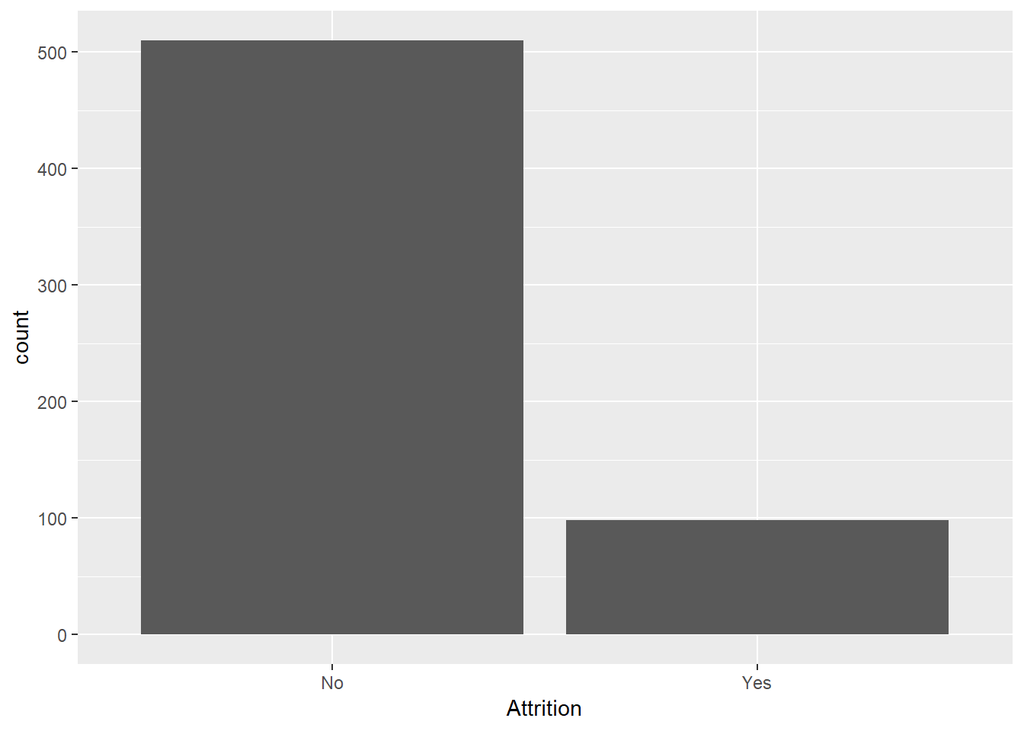

```r
predict.full <- predict(lr.model.full, newdata = test.income)
predict.reduced <- predict(lr.model.reduced, newdata = test.income)

train.income %>% ggplot(aes(Attrition)) + geom_bar(stat = "Count")
```

```r
prop.train <- ddply(train.income, "Attrition", summarize, length(Attrition))
prop.train
```

```
##   Attrition length(Attrition)
## 1        No               510
## 2       Yes                98
```

```r
prop.train[2,2] / prop.train[1, 2]
```

```
## [1] 0.1921569
```

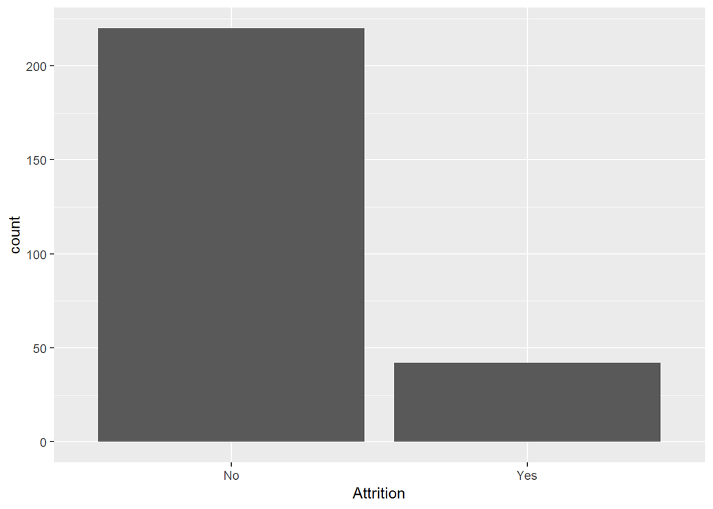

```r
test.income %>% ggplot(aes(Attrition)) + geom_bar(stat = "Count")
```

```r
prop.test <- ddply(test.income, "Attrition", summarize, length(Attrition))
prop.test
```

```
##   Attrition length(Attrition)
## 1        No               220
## 2       Yes                42
```

```r
prop.test[2,2] / prop.test[1, 2]
```

```
## [1] 0.1909091
```

```r
predictions.full <- ifelse(predict.full > 0.5, "Yes", "No")
predictions.reduced <- ifelse(predict.reduced > 0.5, "Yes", "No")
actuals <- test.income$Attrition

conf.mat.full <- table(actuals, predictions.full)
conf.mat.reduced <- table(actuals, predictions.reduced)
confusionMatrix(conf.mat.full)
```

```
## Confusion Matrix and Statistics
##
##        predictions.full
## actuals  No Yes
##     No  210  10
##     Yes  27  15
##
##                Accuracy : 0.8588
##                  95% CI : (0.8106, 0.8986)
##     No Information Rate : 0.9046
##     P-Value [Acc > NIR] : 0.993648
##
##                   Kappa : 0.3727
##
##  Mcnemar's Test P-Value : 0.008529
##
##             Sensitivity : 0.8861
##             Specificity : 0.6000
##          Pos Pred Value : 0.9545
##          Neg Pred Value : 0.3571
##              Prevalence : 0.9046
##          Detection Rate : 0.8015
##    Detection Prevalence : 0.8397
##       Balanced Accuracy : 0.7430
##
##        'Positive' Class : No
##
```

```r
confusionMatrix(conf.mat.reduced)
```

```
## Confusion Matrix and Statistics
##
##        predictions.reduced
## actuals  No Yes
##     No  215   5
##     Yes  28  14
##
##                Accuracy : 0.874
##                  95% CI : (0.8277, 0.9117)
##     No Information Rate : 0.9275
##     P-Value [Acc > NIR] : 0.9992462
##
##                   Kappa : 0.399
##
##  Mcnemar's Test P-Value : 0.0001283
##
##             Sensitivity : 0.8848
##             Specificity : 0.7368
##          Pos Pred Value : 0.9773
##          Neg Pred Value : 0.3333
##              Prevalence : 0.9275
##          Detection Rate : 0.8206
##    Detection Prevalence : 0.8397
##       Balanced Accuracy : 0.8108
##
##        'Positive' Class : No
##
```

reclassifying our response variable in the model predictioni and cutting with different proportions

```r
predict.full.class <- predict(lr.model.full, newdata = test.income, type = "response")
predict.reduced.class <- predict(lr.model.reduced, newdata = test.income, type = "response")
predictions.full.class <- ifelse(predict.full.class > 0.5, "Yes", "No")
predictions.reduced.class <- ifelse(predict.reduced.class > 0.5, "Yes", "No" )

predictions.full.cut <- ifelse(predict.full.class > (1 - 0.1917808), "Yes", "No")
predictions.reduced.cut <- ifelse(predict.reduced.class > (1 - 0.1917808), "Yes", "No" )

conf.mat.full.class <- table(actuals, predictions.full.class)
conf.mat.reduced.class <- table(actuals, predictions.reduced.class)

conf.mat.full.cut <- table(actuals, predictions.full.cut)
conf.mat.reduced.cut <- table(actuals, predictions.reduced.cut)

confusionMatrix(conf.mat.full.class)
```

```
## Confusion Matrix and Statistics
##
##        predictions.full.class
## actuals  No Yes
##     No  205  15
##     Yes  22  20
##
##                Accuracy : 0.8588
##                  95% CI : (0.8106, 0.8986)
##     No Information Rate : 0.8664
##     P-Value [Acc > NIR] : 0.6813
##
##                   Kappa : 0.4375
##
##  Mcnemar's Test P-Value : 0.3239
##
##             Sensitivity : 0.9031
##             Specificity : 0.5714
##          Pos Pred Value : 0.9318
##          Neg Pred Value : 0.4762
##              Prevalence : 0.8664
##          Detection Rate : 0.7824
##    Detection Prevalence : 0.8397
##       Balanced Accuracy : 0.7373
##
##        'Positive' Class : No
##
```

```r
confusionMatrix(conf.mat.reduced.class)
```

```
## Confusion Matrix and Statistics
##
##        predictions.reduced.class
## actuals  No Yes
##     No  213   7
##     Yes  25  17
##
##                Accuracy : 0.8779
##                  95% CI : (0.832, 0.9149)
##     No Information Rate : 0.9084
##     P-Value [Acc > NIR] : 0.961099
##
##                   Kappa : 0.4512
##
##  Mcnemar's Test P-Value : 0.002654
##
##             Sensitivity : 0.8950
##             Specificity : 0.7083
##          Pos Pred Value : 0.9682
##          Neg Pred Value : 0.4048
##              Prevalence : 0.9084
##          Detection Rate : 0.8130
##    Detection Prevalence : 0.8397
##       Balanced Accuracy : 0.8016
##
##        'Positive' Class : No
##
```

```r
confusionMatrix(conf.mat.full.cut)
```

```
## Confusion Matrix and Statistics
##
##        predictions.full.cut
## actuals  No Yes
##     No  216   4
##     Yes  33   9
##
##                Accuracy : 0.8588
##                  95% CI : (0.8106, 0.8986)
##     No Information Rate : 0.9504
##     P-Value [Acc > NIR] : 1
##
##                   Kappa : 0.2721
##
##  Mcnemar's Test P-Value : 4.161e-06
##
##             Sensitivity : 0.8675
##             Specificity : 0.6923
##          Pos Pred Value : 0.9818
##          Neg Pred Value : 0.2143
##              Prevalence : 0.9504
##          Detection Rate : 0.8244
##    Detection Prevalence : 0.8397
##       Balanced Accuracy : 0.7799
##
##        'Positive' Class : No
##
```

```r
confusionMatrix(conf.mat.reduced.cut)
```

```
## Confusion Matrix and Statistics
##
##        predictions.reduced.cut
## actuals  No Yes
##     No  218   2
##     Yes  35   7
##
##                Accuracy : 0.8588
##                  95% CI : (0.8106, 0.8986)
##     No Information Rate : 0.9656
##     P-Value [Acc > NIR] : 1
##
##                   Kappa : 0.231
##
##  Mcnemar's Test P-Value : 1.435e-07
##
##             Sensitivity : 0.8617
##             Specificity : 0.7778
##          Pos Pred Value : 0.9909
##          Neg Pred Value : 0.1667
##              Prevalence : 0.9656
##          Detection Rate : 0.8321
##    Detection Prevalence : 0.8397
##       Balanced Accuracy : 0.8197
##
##        'Positive' Class : No
##
```

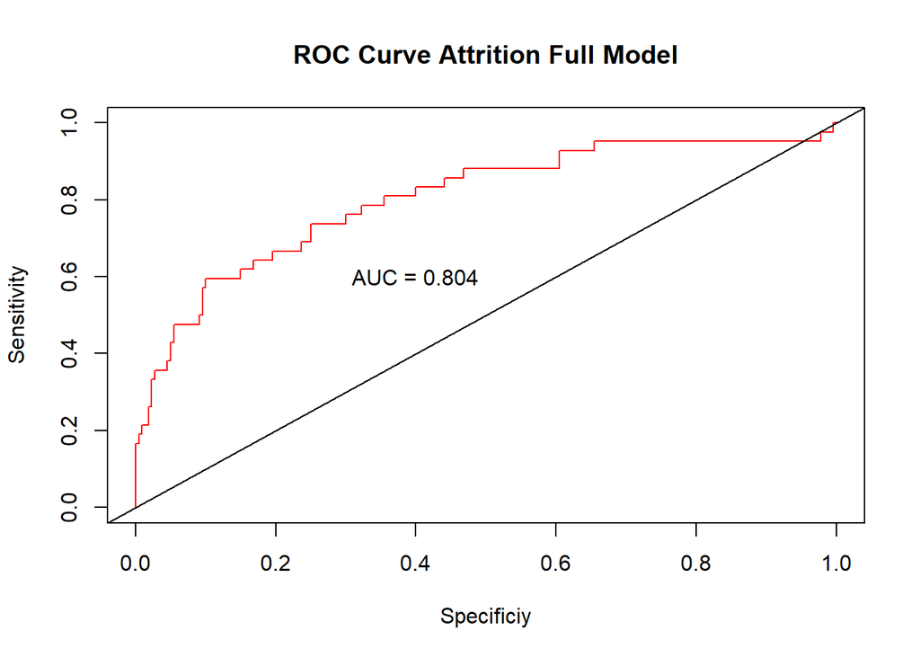

```r
lr.pred.full <- prediction(predict.full, test.income$Attrition)
lr.perf.full <- performance(lr.pred.full, measure = "tpr", x.measure = "fpr")
plot(lr.perf.full, col = rainbow(7), main = "ROC Curve Attrition Full Model", xlab = "Specificiy", ylab = "Sensitivity")
abline(0,1)
auc <- performance(lr.pred.full, "auc")
auc.value <- auc@y.values
text(x = .40, y = .6,paste("AUC = ", round(as.numeric(auc.value[[1]]),3), sep = ""))
```

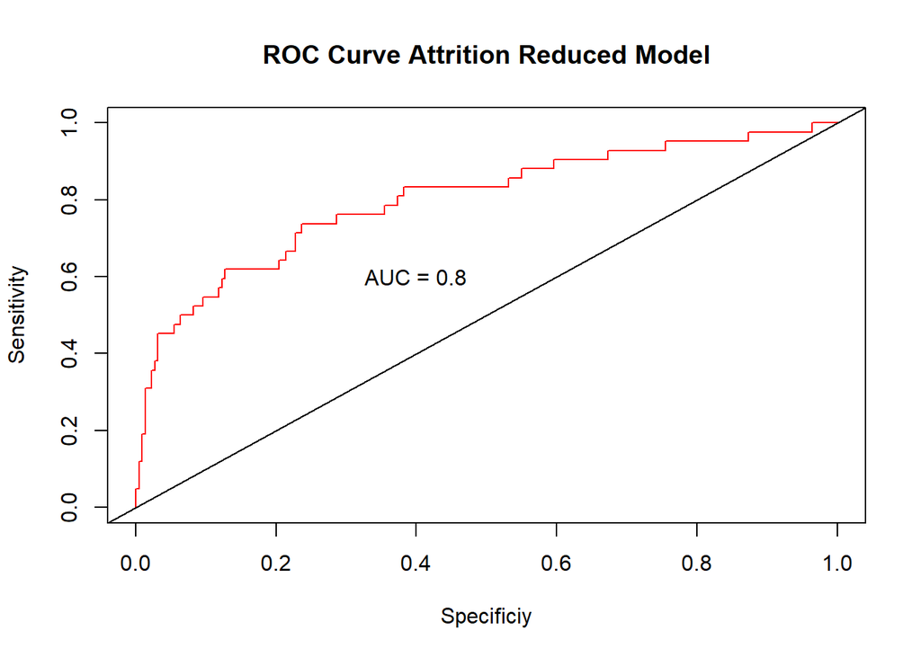

```r
lr.pred.reduced <- prediction(predict.reduced, test.income$Attrition)
lr.perf.reduced <- performance(lr.pred.reduced, measure = "tpr", x.measure = "fpr")
plot(lr.perf.reduced, col = rainbow(7), main = "ROC Curve Attrition Reduced Model", xlab = "Specificiy", ylab = "Sensitivity")
abline(0,1)
auc <- performance(lr.pred.reduced, "auc")
auc.value <- auc@y.values
text(x = .40, y = .6,paste("AUC = ", round(as.numeric(auc.value[[1]]),3), sep = ""))
```

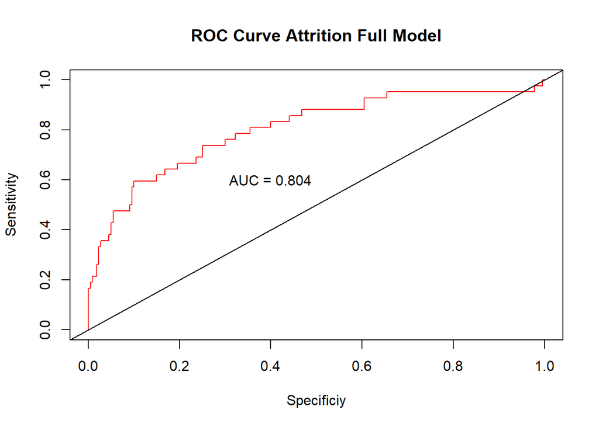

```r
lr.pred.full.class <- prediction(predict.full.class, test.income$Attrition)
lr.perf.full.class <- performance(lr.pred.full.class, measure = "tpr", x.measure = "fpr")
plot(lr.perf.full.class, col = rainbow(7), main = "ROC Curve Attrition Full Model", xlab = "Specificiy", ylab = "Sensitivity")
abline(0,1)
auc <- performance(lr.pred.full.class, "auc")
auc.value <- auc@y.values
text(x = .40, y = .6,paste("AUC = ", round(as.numeric(auc.value[[1]]),3), sep = ""))
```

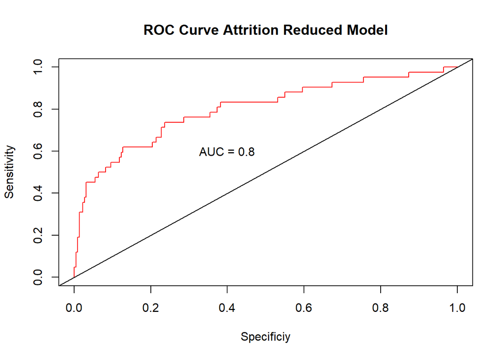

```r
lr.pred.reduced.class <- prediction(predict.reduced.class, test.income$Attrition)
lr.perf.reduced.class <- performance(lr.pred.reduced.class, measure = "tpr", x.measure = "fpr")
plot(lr.perf.reduced.class, col = rainbow(7), main = "ROC Curve Attrition Reduced Model", xlab = "Specificiy", ylab = "Sensitivity")
abline(0,1)
auc <- performance(lr.pred.reduced.class, "auc")
auc.value <- auc@y.values
text(x = .40, y = .6,paste("AUC = ", round(as.numeric(auc.value[[1]]),3), sep = ""))
```

naive bayes

```r
nb.model.full <- naiveBayes(Attrition ~ ., data = train.income)
nb.pred.full <- predict(nb.model.full, newdata = test.income[,names(test.income) != "Attrition"])
predictions <- nb.pred.full
table(predictions, actuals)
```

```
##            actuals
## predictions  No Yes
##         No  188  16
##         Yes  32  26
```

```r
confusionMatrix(table(predictions, actuals))
```

```
## Confusion Matrix and Statistics
##
##            actuals
## predictions  No Yes
##         No  188  16
##         Yes  32  26
##
##                Accuracy : 0.8168
##                  95% CI : (0.7645, 0.8617)
##     No Information Rate : 0.8397
##     P-Value [Acc > NIR] : 0.86249
##
##                   Kappa : 0.4104
##
##  Mcnemar's Test P-Value : 0.03038
##
##             Sensitivity : 0.8545
##             Specificity : 0.6190
##          Pos Pred Value : 0.9216
##          Neg Pred Value : 0.4483
##              Prevalence : 0.8397
##          Detection Rate : 0.7176
##    Detection Prevalence : 0.7786
##       Balanced Accuracy : 0.7368
##
##        'Positive' Class : No
##
```